# Voicing and Gemination - Mixed Effects Modelling

### 5.2.3 Proportion of voicing in the Release Phase (% Voicing Rel)

#### 5.2.3.1 Model specification

We run three models. For model comparisons, we are required to use Maximum Likelihood (ML) on both Optimal and Null models (by adding REML=F). Then we run a second Optimal models with Restricted Maximum Likelihood (REML), to obtain the coefficients (by adding REML=T)

##### 5.2.3.1.1 Optimal model (ML)

```r
durationPropVoiceRel.xmdl.Full.M <- lmer(durationVoicedPerc~voiced.unvoiced_c+singGem_c+sex_c+vowelLength_c+syllType_c+place_c+
                                (voiced.unvoiced_c+singGem_c+vowelLength_c+syllType_c+place_c||speaker)+(1|wordTarget),
                              data = geminationVOT,na.action=na.exclude,
                              REML=F,
                              control = lmerControl(optimizer = "bobyqa",optCtrl=list(maxfun=1e5)))
```

##### 5.2.3.1.2 Optimal model (REML)

```r
durationPropVoiceRel.xmdl.Full.R <- lmer(durationVoicedPerc~voiced.unvoiced_c+singGem_c+sex_c+vowelLength_c+syllType_c+place_c+
                                (voiced.unvoiced_c+singGem_c+vowelLength_c+syllType_c+place_c||speaker)+(1|wordTarget),
                              data = geminationVOT,na.action=na.exclude,
                              REML=T,
                              control = lmerControl(optimizer = "bobyqa",optCtrl=list(maxfun=1e5)))
```

##### 5.2.3.1.3 Null model (ML)

```r
durationPropVoiceRel.xmdl.Null.M <- lmer(durationVoicedPerc~1+
                                (voiced.unvoiced_c+singGem_c+vowelLength_c+syllType_c+place_c||speaker)+(1|wordTarget),
                              data = geminationVOT,na.action=na.exclude,
                              REML=F,
                              control = lmerControl(optimizer = "bobyqa",optCtrl=list(maxfun=1e5)))
```

#### 5.2.3.2 Results of our model

##### 5.2.3.2.1 Model comparisons

```r
anova(durationPropVoiceRel.xmdl.Null.M,durationPropVoiceRel.xmdl.Full.M)
```

```
Data: geminationVOT
Models:
durationPropVoiceRel.xmdl.Null.M: durationVoicedPerc ~ 1 + (voiced.unvoiced_c + singGem_c + vowelLength_c +
durationPropVoiceRel.xmdl.Null.M:     syllType_c + place_c || speaker) + (1 | wordTarget)
durationPropVoiceRel.xmdl.Full.M: durationVoicedPerc ~ voiced.unvoiced_c + singGem_c + sex_c +
durationPropVoiceRel.xmdl.Full.M:     vowelLength_c + syllType_c + place_c + (voiced.unvoiced_c +
durationPropVoiceRel.xmdl.Full.M:     singGem_c + vowelLength_c + syllType_c + place_c || speaker) +
durationPropVoiceRel.xmdl.Full.M:     (1 | wordTarget)
                                 Df   AIC   BIC  logLik deviance
durationPropVoiceRel.xmdl.Null.M  9 17398 17447 -8689.8    17380
durationPropVoiceRel.xmdl.Full.M 15 17310 17392 -8639.8    17280
                                  Chisq Chi Df Pr(>Chisq)
durationPropVoiceRel.xmdl.Null.M
durationPropVoiceRel.xmdl.Full.M 99.948      6  < 2.2e-16 ***
---
Signif. codes:  0 ‘***’ 0.001 ‘**’ 0.01 ‘*’ 0.05 ‘.’ 0.1 ‘ ’ 1
```

As can be seen, our optimal model improved the model fit.

##### 5.2.3.2.2 Residuals

We inspect our model below, by looking at the residuals. There are minor deviations observed, due to the nature of our data.

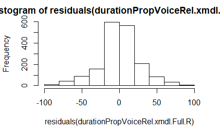

```r
hist(residuals(durationPropVoiceRel.xmdl.Full.R))
```

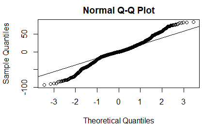

```r
qqnorm(residuals(durationPropVoiceRel.xmdl.Full.R)); qqline(residuals(durationPropVoiceRel.xmdl.Full.R))
```

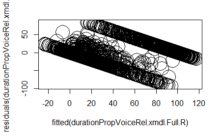

```r
plot(fitted(durationPropVoiceRel.xmdl.Full.R),residuals(durationPropVoiceRel.xmdl.Full.R), cex = 4)
```

##### 5.2.3.2.3 Summary of model

```r
summary(durationPropVoiceRel.xmdl.Full.R)
```

```
Linear mixed model fit by REML. t-tests use Satterthwaite's method [
lmerModLmerTest]
Formula: durationVoicedPerc ~ voiced.unvoiced_c + singGem_c + sex_c +
    vowelLength_c + syllType_c + place_c + (voiced.unvoiced_c +
    singGem_c + vowelLength_c + syllType_c + place_c || speaker) +
    (1 | wordTarget)
   Data: geminationVOT
Control:
lmerControl(optimizer = "bobyqa", optCtrl = list(maxfun = 1e+05))

REML criterion at convergence: 17250.1

Scaled residuals:
    Min      1Q  Median      3Q     Max
-3.3311 -0.4157 -0.0002  0.4979  2.9874

Random effects:
 Groups     Name              Variance Std.Dev.
 wordTarget (Intercept)        55.52    7.451
 speaker    place_c             0.00    0.000
 speaker.1  syllType_c         36.37    6.031
 speaker.2  vowelLength_c      65.13    8.070
 speaker.3  singGem_c         112.70   10.616
 speaker.4  voiced.unvoiced_c 546.69   23.381
 speaker.5  (Intercept)        66.85    8.176
 Residual                     791.28   28.130
Number of obs: 1793, groups:  wordTarget, 98; speaker, 20

Fixed effects:
                  Estimate Std. Error       df t value Pr(>|t|)
(Intercept)        38.6360     2.5703  41.8188  15.032  < 2e-16 ***
voiced.unvoiced_c  63.1715     5.7754  24.5602  10.938 6.30e-11 ***
singGem_c         -23.5631     3.2786  33.0544  -7.187 3.05e-08 ***
sex_c             -20.6862     3.9928  16.9392  -5.181 7.60e-05 ***
vowelLength_c      -7.8711     2.9311  39.7212  -2.685  0.01052 *
syllType_c          8.7082     3.2335  50.8425   2.693  0.00956 **
place_c             0.7589     3.2208  91.9741   0.236  0.81425
---
Signif. codes:  0 ‘***’ 0.001 ‘**’ 0.01 ‘*’ 0.05 ‘.’ 0.1 ‘ ’ 1

Correlation of Fixed Effects:
            (Intr) vcd.n_ sngGm_ sex_c  vwlLn_ syllT_
vocd.nvcd_c  0.056
singGem_c   -0.127 -0.011
sex_c       -0.007  0.002  0.002
vowlLngth_c  0.182 -0.050  0.044 -0.002
syllType_c   0.384  0.016 -0.245 -0.003  0.202
place_c      0.379  0.227 -0.008  0.000 -0.046  0.030
```

#### 5.2.3.3 Figures

The figure presented below, uses the predicted (or fitted) values; these are the values *adjusted* by the statistical model. These take into account the random effects’ structure as well as the fixed effects’ structure.

##### 5.2.3.3.1 Using “predict”

The following code is used to record the predicted (or fitted) values into the same data-frame. This will then be used to plot the results of the model

```r
geminationVOT$fitted_PropVoiceRel <- predict(lmer(durationVoicedPerc~voiced.unvoiced_c+singGem_c+sex_c+vowelLength_c+syllType_c+place_c+
                                (voiced.unvoiced_c+singGem_c+vowelLength_c+syllType_c+place_c||speaker)+(1|wordTarget),
                              data = geminationVOT,na.action=na.exclude,
                              REML=T,
                              control = lmerControl(optimizer = "bobyqa",optCtrl=list(maxfun=1e5)))
)
```

##### 5.2.3.3.2 Plotting the results

We use “ggplot2” to plot the results. This will use the “predicted” (or fitted) values adjusted by our statistical model. The dashed lines *within* the boxplots are the mean values; the median is marked by the horizontal straight lines.

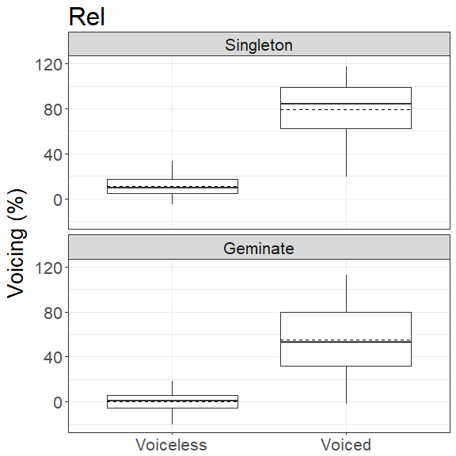

```r
labels <- c(singleton = "Singleton", geminate = "Geminate")
ggPropVoiceRelByVoice <- ggplot(geminationVOT, aes(y=fitted_PropVoiceRel, x=voiced.unvoiced)) +
  geom_boxplot(outlier.colour = "NA",na.rm=TRUE) +
  stat_summary(fun.y = mean, geom = "errorbar", aes(ymax = ..y.., ymin = ..y..),
               width = .75, linetype = "dashed") +
  ylab(expression(paste("Voicing (%)"))) + labs(title = "Rel") +
  coord_cartesian(ylim = c(-20,120)) +
  theme_set(theme_bw()) + theme(text=element_text(size=20)) +
  theme(axis.title.x = element_blank()) + theme(legend.title=element_blank()) +
  scale_x_discrete(breaks=levels(geminationVOT$voiced.unvoiced), labels=c("Voiceless","Voiced")) +
  facet_wrap(~singGem,ncol=1,labeller=labeller(singGem = labels))
ggPropVoiceRelByVoice
```

#### 5.2.3.4 Pairwise comparisons

After running our statistical model above, we wanted to evaluate whether the differences observed between “voicing” and “gemination” is statistically significant (or not). We present the means and standard deviations for each of the four-way contrast based on the predicted (or fitted) values.

##### 5.2.3.4.1 Descriptive statistics

The predicted means and SDs of the Proportion of voicing in the Release Phase (% Voicing Rel) are provided below. As can be seen, there are already differences observed related to both “voicing” and “gemination”.

```r
# using "dplyr"
geminationVOT %>% group_by(singGem:voiced.unvoiced) %>% summarise(mean(fitted_PropVoiceRel), sd(fitted_PropVoiceRel))
```

| singGem:voiced.unvoiced | mean(fitted_PropVoiceRel) | sd(fitted_PropVoiceRel) |
| --- | --- | --- |
| singleton:voiceless | 10.8391712 | 8.555312 |
| singleton:voiced | 79.5610700 | 23.000105 |
| geminate:voiceless | 0.4157101 | 7.868659 |
| geminate:voiced | 55.3439010 | 26.676593 |

##### 5.2.3.4.2 Pairwise t-test with FDR corrections

We used the pairwise t-test as available in base R. The input was the predicted (or fitted) values as adjusted by our statistical model. It was not possible to directly use our statistical model’s output to compare models, given that our LMM model was looking at overall change as a main effect rather than as a simple effect’s model. This is why we have used the predicted (or fitted) values as adjusted by our statistical model; the results are the same if we were to use the “actual” results rather than the predicted ones. We used FDR (for False Discovery Rate) correction for multiple comparisons as this allowed for correcting for bias in the differences in doing multiple comparisons.

```r
pairwise.t.test(geminationVOT$fitted_PropVoiceRel, geminationVOT$singGem:geminationVOT$voiced.unvoiced, p.adj = "fdr")
```

```
    Pairwise comparisons using t tests with pooled SD

data:  geminationVOT$fitted_PropVoiceRel and geminationVOT$singGem:geminationVOT$voiced.unvoiced

                   singleton:voiceless singleton:voiced
singleton:voiced   < 2e-16             -
geminate:voiceless 3.7e-12             < 2e-16
geminate:voiced    < 2e-16             < 2e-16
                   geminate:voiceless
singleton:voiced   -
geminate:voiceless -
geminate:voiced    < 2e-16

P value adjustment method: fdr
```

## 5.3 Intensity (dB)

Within Intensity, we have computed the intensity at four locations: At the Offset of the preceding vowel (V1Offset), at the onset of the Release Phase (RelOnset), at the Offset of the Release Phase (RelOffset) and at the Onset of the following vowel (V2Offset).

### 5.3.1 At the offset of the preceding vowel

#### 5.3.1.1 Model specification

We run three models. For model comparisons, we are required to use Maximum Likelihood (ML) on both Optimal and Null models (by adding REML=F). Then we run a second Optimal models with Restricted Maximum Likelihood (REML), to obtain the coefficients (by adding REML=T)

##### 5.3.1.1.1 Optimal model (ML)

```r
intensityV1Offset.xmdl.Full.M <- lmer(intensityOffset~voiced.unvoiced_c+singGem_c+sex_c+vowelLength_c+syllType_c+place_c+
                                (voiced.unvoiced_c+singGem_c+vowelLength_c+syllType_c+place_c||speaker)+(1|wordTarget),
                              data = geminationV1,na.action=na.exclude,
                              REML=F,
                              control = lmerControl(optimizer = "bobyqa",optCtrl=list(maxfun=1e5)))
```

##### 5.3.1.1.2 Optimal model (REML)

```r
intensityV1Offset.xmdl.Full.R <- lmer(intensityOffset~voiced.unvoiced_c+singGem_c+sex_c+vowelLength_c+syllType_c+place_c+
                                (voiced.unvoiced_c+singGem_c+vowelLength_c+syllType_c+place_c||speaker)+(1|wordTarget),
                              data = geminationV1,na.action=na.exclude,
                              REML=T,
                              control = lmerControl(optimizer = "bobyqa",optCtrl=list(maxfun=1e5)))
```

##### 5.3.1.1.3 Null model (ML)

```r
intensityV1Offset.xmdl.Null.M <- lmer(intensityOffset~1+
                                (voiced.unvoiced_c+singGem_c+vowelLength_c+syllType_c+place_c||speaker)+(1|wordTarget),
                              data = geminationV1,na.action=na.exclude,
                              REML=F,
                              control = lmerControl(optimizer = "bobyqa",optCtrl=list(maxfun=1e5)))
```

#### 5.3.1.2 Results of our model

##### 5.3.1.2.1 Model comparisons

```r
anova(intensityV1Offset.xmdl.Null.M,intensityV1Offset.xmdl.Full.M)
```

```
Data: geminationV1
Models:
intensityV1Offset.xmdl.Null.M: intensityOffset ~ 1 + (voiced.unvoiced_c + singGem_c + vowelLength_c +
intensityV1Offset.xmdl.Null.M:     syllType_c + place_c || speaker) + (1 | wordTarget)
intensityV1Offset.xmdl.Full.M: intensityOffset ~ voiced.unvoiced_c + singGem_c + sex_c + vowelLength_c +
intensityV1Offset.xmdl.Full.M:     syllType_c + place_c + (voiced.unvoiced_c + singGem_c + vowelLength_c +
intensityV1Offset.xmdl.Full.M:     syllType_c + place_c || speaker) + (1 | wordTarget)
                              Df    AIC  BIC  logLik deviance  Chisq
intensityV1Offset.xmdl.Null.M  9 9091.6 9141 -4536.8   9073.6
intensityV1Offset.xmdl.Full.M 15 8978.6 9061 -4474.3   8948.6 124.98
                              Chi Df Pr(>Chisq)
intensityV1Offset.xmdl.Null.M
intensityV1Offset.xmdl.Full.M      6  < 2.2e-16 ***
---
Signif. codes:  0 ‘***’ 0.001 ‘**’ 0.01 ‘*’ 0.05 ‘.’ 0.1 ‘ ’ 1
```

As can be seen, our optimal model improved the model fit.

##### 5.3.1.2.2 Residuals

We inspect our model below, by looking at the residuals. There are minor deviations observed, due to the nature of our data.

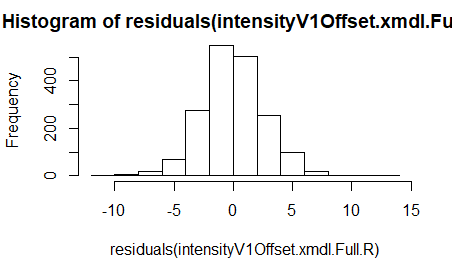

```r
hist(residuals(intensityV1Offset.xmdl.Full.R))
```

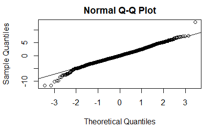

```r
qqnorm(residuals(intensityV1Offset.xmdl.Full.R)); qqline(residuals(intensityV1Offset.xmdl.Full.R))
```

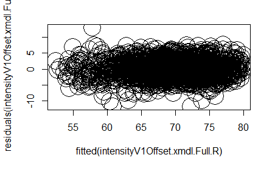

```r
plot(fitted(intensityV1Offset.xmdl.Full.R),residuals(intensityV1Offset.xmdl.Full.R), cex = 4)
```

##### 5.3.1.2.3 Summary of model

```r
summary(intensityV1Offset.xmdl.Full.R)
```

```
Linear mixed model fit by REML. t-tests use Satterthwaite's method [
lmerModLmerTest]
Formula:
intensityOffset ~ voiced.unvoiced_c + singGem_c + sex_c + vowelLength_c +
    syllType_c + place_c + (voiced.unvoiced_c + singGem_c + vowelLength_c +
    syllType_c + place_c || speaker) + (1 | wordTarget)
   Data: geminationV1
Control:
lmerControl(optimizer = "bobyqa", optCtrl = list(maxfun = 1e+05))

REML criterion at convergence: 8945.9

Scaled residuals:
    Min      1Q  Median      3Q     Max
-4.3661 -0.6119 -0.0346  0.5985  4.8353

Random effects:
 Groups     Name              Variance Std.Dev.
 wordTarget (Intercept)        0.9241  0.9613
 speaker    place_c            0.1154  0.3398
 speaker.1  syllType_c         1.1642  1.0790
 speaker.2  vowelLength_c      0.7610  0.8724
 speaker.3  singGem_c          0.0000  0.0000
 speaker.4  voiced.unvoiced_c  0.8781  0.9371
 speaker.5  (Intercept)       16.8285  4.1023
 Residual                      7.3419  2.7096
Number of obs: 1793, groups:  wordTarget, 98; speaker, 20

Fixed effects:
                  Estimate Std. Error      df t value Pr(>|t|)
(Intercept)        67.3528     0.9409 19.5721  71.585  < 2e-16 ***
voiced.unvoiced_c   2.3547     0.3530 53.0072   6.671 1.52e-08 ***
singGem_c           0.1617     0.2613 92.9803   0.619  0.53760
sex_c              -5.6355     1.8425 18.0004  -3.059  0.00676 **
vowelLength_c      -1.5195     0.3309 50.8626  -4.592 2.91e-05 ***
syllType_c         -3.7793     0.4173 56.6523  -9.057 1.31e-12 ***
place_c            -1.8546     0.3808 65.8930  -4.870 7.30e-06 ***
---
Signif. codes:  0 ‘***’ 0.001 ‘**’ 0.01 ‘*’ 0.05 ‘.’ 0.1 ‘ ’ 1

Correlation of Fixed Effects:
            (Intr) vcd.n_ sngGm_ sex_c  vwlLn_ syllT_
vocd.nvcd_c  0.034
singGem_c   -0.059 -0.030
sex_c        0.000  0.001  0.000
vowlLngth_c  0.059 -0.097  0.065  0.000
syllType_c   0.109  0.027 -0.317 -0.001  0.186
place_c      0.118  0.421 -0.012  0.000 -0.046  0.026
```

#### 5.3.1.3 Figures

The figure presented below, uses the predicted (or fitted) values; these are the values *adjusted* by the statistical model. These take into account the random effects’ structure as well as the fixed effects’ structure.

##### 5.3.1.3.1 Using “predict”

The following code is used to record the predicted (or fitted) values into the same data-frame. This will then be used to plot the results of the model

```r
geminationV1$fitted_V1IntensityOffset <- predict(lmer(intensityOffset~voiced.unvoiced_c+singGem_c+sex_c+vowelLength_c+syllType_c+place_c+
                                (voiced.unvoiced_c+singGem_c+vowelLength_c+syllType_c+place_c||speaker)+(1|wordTarget),
                              data = geminationV1,na.action=na.exclude,
                              REML=T,
                              control = lmerControl(optimizer = "bobyqa",optCtrl=list(maxfun=1e5)))
)
```

##### 5.3.1.3.2 Plotting the results

We use “ggplot2” to plot the results. This will use the “predicted” (or fitted) values adjusted by our statistical model. The dashed lines *within* the boxplots are the mean values; the median is marked by the horizontal straight lines.

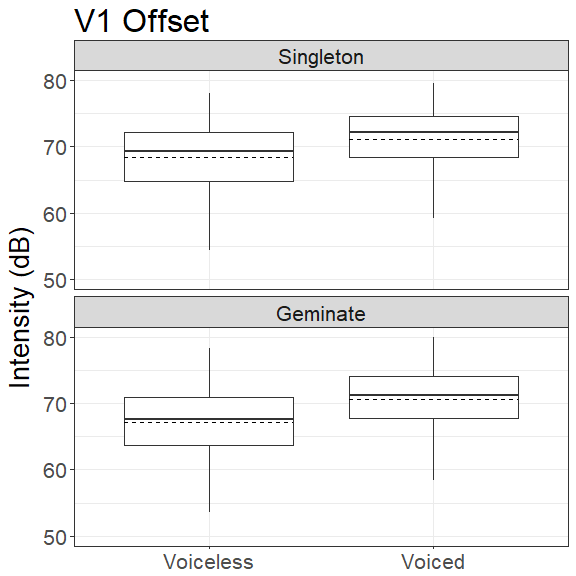

```r
labels <- c(singleton = "Singleton", geminate = "Geminate")
ggIntensityV1OffsetByVoice <- ggplot(geminationV1, aes(y=fitted_V1IntensityOffset, x=voiced.unvoiced)) +
  geom_boxplot(outlier.colour = "NA",na.rm=TRUE) +
  stat_summary(fun.y = mean, geom = "errorbar", aes(ymax = ..y.., ymin = ..y..),
               width = .75, linetype = "dashed") +
  ylab(expression(paste("Intensity (dB)"))) + labs(title = "V1 Offset") +
  theme_set(theme_bw()) + theme(text=element_text(size=20)) +
  coord_cartesian(ylim = c(50,80)) +
  theme(axis.title.x = element_blank()) + theme(legend.title=element_blank()) +
  scale_x_discrete(breaks=levels(geminationV1$voiced.unvoiced), labels=c("Voiceless","Voiced")) +
  facet_wrap(~singGem,ncol=1,labeller=labeller(singGem = labels))
ggIntensityV1OffsetByVoice
```

#### 5.3.1.4 Pairwise comparisons

After running our statistical model above, we wanted to evaluate whether the differences observed between “voicing” and “gemination” is statistically significant (or not). We present the means and standard deviations for each of the four-way contrast based on the predicted (or fitted) values.

##### 5.3.1.4.1 Descriptive statistics

The predicted means and SDs of the Intensity at the Offset of the preceding vowel (V1Offset) are provided below. As can be seen, there are already differences observed related to both “voicing” and “gemination”.

```r
# using "dplyr"
geminationV1 %>% group_by(singGem:voiced.unvoiced) %>% summarise(mean(fitted_V1IntensityOffset), sd(fitted_V1IntensityOffset))
```

| singGem:voiced.unvoiced | mean(fitted_V1IntensityOffset) | sd(fitted_V1IntensityOffset) |
| --- | --- | --- |
| singleton:voiceless | 68.36837 | 5.215482 |
| singleton:voiced | 71.12120 | 5.156254 |
| geminate:voiceless | 67.11216 | 5.270905 |
| geminate:voiced | 70.60397 | 5.016623 |

##### 5.3.1.4.2 Pairwise t-test with FDR corrections

We used the pairwise t-test as available in base R. The input was the predicted (or fitted) values as adjusted by our statistical model. It was not possible to directly use our statistical model’s output to compare models, given that our LMM model was looking at overall change as a main effect rather than as a simple effect’s model. This is why we have used the predicted (or fitted) values as adjusted by our statistical model; the results are the same if we were to use the “actual” results rather than the predicted ones. We used FDR (for False Discovery Rate) correction for multiple comparisons as this allowed for correcting for bias in the differences in doing multiple comparisons.

```r
pairwise.t.test(geminationV1$fitted_V1IntensityOffset, geminationV1$singGem:geminationV1$voiced.unvoiced, p.adj = "fdr")
```

```
    Pairwise comparisons using t tests with pooled SD

data:  geminationV1$fitted_V1IntensityOffset and geminationV1$singGem:geminationV1$voiced.unvoiced

                   singleton:voiceless singleton:voiced
singleton:voiced   5.5e-13             -
geminate:voiceless 0.0013              < 2e-16
geminate:voiced    7.6e-10             0.1047
                   geminate:voiceless
singleton:voiced   -
geminate:voiceless -
geminate:voiced    < 2e-16

P value adjustment method: fdr
```

### 5.3.2 At the onset of the Release phase

#### 5.3.2.1 Model specification

We run three models. For model comparisons, we are required to use Maximum Likelihood (ML) on both Optimal and Null models (by adding REML=F). Then we run a second Optimal models with Restricted Maximum Likelihood (REML), to obtain the coefficients (by adding REML=T)

##### 5.3.2.1.1 Optimal model (ML)

```r
intensityRelOnset.xmdl.Full.M <- lmer(intensityOnset~voiced.unvoiced_c+singGem_c+sex_c+vowelLength_c+syllType_c+place_c+
                                (voiced.unvoiced_c+singGem_c+vowelLength_c+syllType_c+place_c||speaker)+(1|wordTarget),
                              data = geminationVOT,na.action=na.exclude,
                              REML=F,
                              control = lmerControl(optimizer = "bobyqa",optCtrl=list(maxfun=1e5)))
```

##### 5.3.2.1.2 Optimal model (REML)

```r
intensityRelOnset.xmdl.Full.R <- lmer(intensityOnset~voiced.unvoiced_c+singGem_c+sex_c+vowelLength_c+syllType_c+place_c+
                                (voiced.unvoiced_c+singGem_c+vowelLength_c+syllType_c+place_c||speaker)+(1|wordTarget),
                              data = geminationVOT,na.action=na.exclude,
                              REML=T,
                              control = lmerControl(optimizer = "bobyqa",optCtrl=list(maxfun=1e5)))
```

##### 5.3.2.1.3 Null model (ML)

```r
intensityRelOnset.xmdl.Null.M <- lmer(intensityOnset~1+
                                (voiced.unvoiced_c+singGem_c+vowelLength_c+syllType_c+place_c||speaker)+(1|wordTarget),
                              data = geminationVOT,na.action=na.exclude,
                              REML=F,
                              control = lmerControl(optimizer = "bobyqa",optCtrl=list(maxfun=1e5)))
```

#### 5.3.2.2 Results of our model

##### 5.3.2.2.1 Model comparisons

```r
anova(intensityRelOnset.xmdl.Null.M,intensityRelOnset.xmdl.Full.M)
```

```
Data: geminationVOT
Models:
intensityRelOnset.xmdl.Null.M: intensityOnset ~ 1 + (voiced.unvoiced_c + singGem_c + vowelLength_c +
intensityRelOnset.xmdl.Null.M:     syllType_c + place_c || speaker) + (1 | wordTarget)
intensityRelOnset.xmdl.Full.M: intensityOnset ~ voiced.unvoiced_c + singGem_c + sex_c + vowelLength_c +
intensityRelOnset.xmdl.Full.M:     syllType_c + place_c + (voiced.unvoiced_c + singGem_c + vowelLength_c +
intensityRelOnset.xmdl.Full.M:     syllType_c + place_c || speaker) + (1 | wordTarget)
                              Df    AIC    BIC  logLik deviance  Chisq
intensityRelOnset.xmdl.Null.M  9 9512.7 9562.1 -4747.3   9494.7
intensityRelOnset.xmdl.Full.M 15 9440.9 9523.3 -4705.5   9410.9 83.755
                              Chi Df Pr(>Chisq)
intensityRelOnset.xmdl.Null.M
intensityRelOnset.xmdl.Full.M      6  5.977e-16 ***
---
Signif. codes:  0 ‘***’ 0.001 ‘**’ 0.01 ‘*’ 0.05 ‘.’ 0.1 ‘ ’ 1
```

As can be seen, our optimal model improved the model fit.

##### 5.3.2.2.2 Residuals

We inspect our model below, by looking at the residuals. There are minor deviations observed, due to the nature of our data.

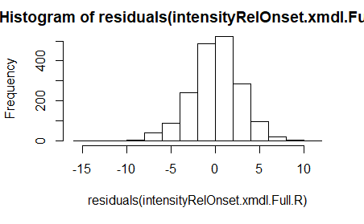

```r
hist(residuals(intensityRelOnset.xmdl.Full.R))
```

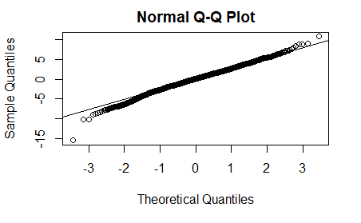

```r
qqnorm(residuals(intensityRelOnset.xmdl.Full.R)); qqline(residuals(intensityRelOnset.xmdl.Full.R))
```

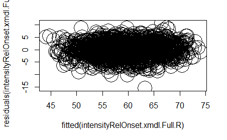

```r
plot(fitted(intensityRelOnset.xmdl.Full.R),residuals(intensityRelOnset.xmdl.Full.R), cex = 4)
```

##### 5.3.2.2.3 Summary of model

```r
summary(intensityRelOnset.xmdl.Full.R)
```

```
Linear mixed model fit by REML. t-tests use Satterthwaite's method [
lmerModLmerTest]
Formula:
intensityOnset ~ voiced.unvoiced_c + singGem_c + sex_c + vowelLength_c +
    syllType_c + place_c + (voiced.unvoiced_c + singGem_c + vowelLength_c +
    syllType_c + place_c || speaker) + (1 | wordTarget)
   Data: geminationVOT
Control:
lmerControl(optimizer = "bobyqa", optCtrl = list(maxfun = 1e+05))

REML criterion at convergence: 9403.7

Scaled residuals:
    Min      1Q  Median      3Q     Max
-5.2016 -0.5727  0.0334  0.6051  3.6262

Random effects:
 Groups     Name              Variance Std.Dev.
 wordTarget (Intercept)        2.0187  1.4208
 speaker    place_c            3.6786  1.9180
 speaker.1  syllType_c         1.8039  1.3431
 speaker.2  vowelLength_c      0.8808  0.9385
 speaker.3  singGem_c          1.1726  1.0829
 speaker.4  voiced.unvoiced_c  9.9030  3.1469
 speaker.5  (Intercept)       12.5941  3.5488
 Residual                      8.8587  2.9764
Number of obs: 1793, groups:  wordTarget, 98; speaker, 20

Fixed effects:
                  Estimate Std. Error       df t value Pr(>|t|)
(Intercept)       59.33375    0.84419 22.02045  70.285  < 2e-16 ***
voiced.unvoiced_c  5.43892    0.80469 28.71351   6.759 2.14e-07 ***
singGem_c         -2.34891    0.43301 65.32732  -5.425 9.08e-07 ***
sex_c             -3.79889    1.60302 17.95114  -2.370  0.02921 *
vowelLength_c     -2.59166    0.42277 71.64730  -6.130 4.30e-08 ***
syllType_c         0.09273    0.55597 67.37955   0.167  0.86803
place_c            1.89781    0.66917 55.03426   2.836  0.00638 **
---
Signif. codes:  0 ‘***’ 0.001 ‘**’ 0.01 ‘*’ 0.05 ‘.’ 0.1 ‘ ’ 1

Correlation of Fixed Effects:
            (Intr) vcd.n_ sngGm_ sex_c  vwlLn_ syllT_
vocd.nvcd_c  0.031
singGem_c   -0.075 -0.015
sex_c       -0.001  0.000  0.001
vowlLngth_c  0.097 -0.063  0.058  0.000
syllType_c   0.173  0.016 -0.270 -0.001  0.207
place_c      0.141  0.199 -0.008 -0.002 -0.039  0.020
```

#### 5.3.2.3 Figures

The figure presented below, uses the predicted (or fitted) values; these are the values *adjusted* by the statistical model. These take into account the random effects’ structure as well as the fixed effects’ structure.

##### 5.3.2.3.1 Using “predict”

The following code is used to record the predicted (or fitted) values into the same data-frame. This will then be used to plot the results of the model

```r
geminationVOT$fitted_RelIntensityOnset <- predict(lmer(intensityOnset~voiced.unvoiced_c+singGem_c+sex_c+vowelLength_c+syllType_c+place_c+
                                (voiced.unvoiced_c+singGem_c+vowelLength_c+syllType_c+place_c||speaker)+(1|wordTarget),
                              data = geminationVOT,na.action=na.exclude,
                              REML=T,
                              control = lmerControl(optimizer = "bobyqa",optCtrl=list(maxfun=1e5)))
)
```

##### 5.3.2.3.2 Plotting the results

We use “ggplot2” to plot the results. This will use the “predicted” (or fitted) values adjusted by our statistical model. The dashed lines *within* the boxplots are the mean values; the median is marked by the horizontal straight lines.

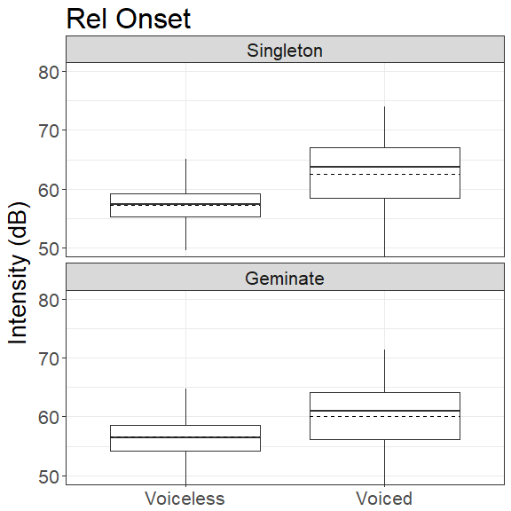

```r
labels <- c(singleton = "Singleton", geminate = "Geminate")
ggIntensityRelOnsetByVoice <- ggplot(geminationVOT, aes(y=fitted_RelIntensityOnset, x=voiced.unvoiced)) +
  geom_boxplot(outlier.colour = "NA",na.rm=TRUE) +
  stat_summary(fun.y = mean, geom = "errorbar", aes(ymax = ..y.., ymin = ..y..),
               width = .75, linetype = "dashed") +
  ylab(expression(paste("Intensity (dB)"))) + labs(title = "Rel Onset") +
  theme_set(theme_bw()) + theme(text=element_text(size=20)) +
  coord_cartesian(ylim = c(50,80)) +
  theme(axis.title.x = element_blank()) + theme(legend.title=element_blank()) +
  scale_x_discrete(breaks=levels(geminationVOT$voiced.unvoiced), labels=c("Voiceless","Voiced")) +
  facet_wrap(~singGem,ncol=1,labeller=labeller(singGem = labels))
ggIntensityRelOnsetByVoice
```

#### 5.3.2.4 Pairwise comparisons

After running our statistical model above, we wanted to evaluate whether the differences observed between “voicing” and “gemination” is statistically significant (or not). We present the means and standard deviations for each of the four-way contrast based on the predicted (or fitted) values.

##### 5.3.2.4.1 Descriptive statistics

The predicted means and SDs of the Intensity at the Onset of the Release phase (RelOnset) are provided below. As can be seen, there are already differences observed related to both “voicing” and “gemination”.

```r
# using "dplyr"
geminationVOT %>% group_by(singGem:voiced.unvoiced) %>% summarise(mean(fitted_RelIntensityOnset), sd(fitted_RelIntensityOnset))
```

| singGem:voiced.unvoiced | mean(fitted_RelIntensityOnset) | sd(fitted_RelIntensityOnset) |
| --- | --- | --- |
| singleton:voiceless | 57.23269 | 3.457614 |
| singleton:voiced | 62.55737 | 5.823897 |
| geminate:voiceless | 56.59479 | 3.487049 |
| geminate:voiced | 60.11648 | 5.439174 |

##### 5.3.2.4.2 Pairwise t-test with FDR corrections

We used the pairwise t-test as available in base R. The input was the predicted (or fitted) values as adjusted by our statistical model. It was not possible to directly use our statistical model’s output to compare models, given that our LMM model was looking at overall change as a main effect rather than as a simple effect’s model. This is why we have used the predicted (or fitted) values as adjusted by our statistical model; the results are the same if we were to use the “actual” results rather than the predicted ones. We used FDR (for False Discovery Rate) correction for multiple comparisons as this allowed for correcting for bias in the differences in doing multiple comparisons.

```r
pairwise.t.test(geminationVOT$fitted_RelIntensityOnset, geminationVOT$singGem:geminationVOT$voiced.unvoiced, p.adj = "fdr")
```

```
    Pairwise comparisons using t tests with pooled SD

data:  geminationVOT$fitted_RelIntensityOnset and geminationVOT$singGem:geminationVOT$voiced.unvoiced

                   singleton:voiceless singleton:voiced
singleton:voiced   < 2e-16             -
geminate:voiceless 0.078               < 2e-16
geminate:voiced    < 2e-16             9.7e-16
                   geminate:voiceless
singleton:voiced   -
geminate:voiceless -
geminate:voiced    < 2e-16

P value adjustment method: fdr
```

### 5.3.3 At the offset of the Release phase

#### 5.3.3.1 Model specification

We run three models. For model comparisons, we are required to use Maximum Likelihood (ML) on both Optimal and Null models (by adding REML=F). Then we run a second Optimal models with Restricted Maximum Likelihood (REML), to obtain the coefficients (by adding REML=T)

##### 5.3.3.1.1 Optimal model (ML)

```r
intensityRelOffset.xmdl.Full.M <- lmer(intensityOffset~voiced.unvoiced_c+singGem_c+sex_c+vowelLength_c+syllType_c+place_c+
                                (voiced.unvoiced_c+singGem_c+vowelLength_c+syllType_c+place_c||speaker)+(1|wordTarget),
                              data = geminationVOT,na.action=na.exclude,
                              REML=F,
                              control = lmerControl(optimizer = "bobyqa",optCtrl=list(maxfun=1e5)))
```

##### 5.3.3.1.2 Optimal model (REML)

```r
intensityRelOffset.xmdl.Full.R <- lmer(intensityOffset~voiced.unvoiced_c+singGem_c+sex_c+vowelLength_c+syllType_c+place_c+
                                (voiced.unvoiced_c+singGem_c+vowelLength_c+syllType_c+place_c||speaker)+(1|wordTarget),
                              data = geminationVOT,na.action=na.exclude,
                              REML=T,
                              control = lmerControl(optimizer = "bobyqa",optCtrl=list(maxfun=1e5)))
```

##### 5.3.3.1.3 Null model (ML)

```r
intensityRelOffset.xmdl.Null.M <- lmer(intensityOffset~1+
                                (voiced.unvoiced_c+singGem_c+vowelLength_c+syllType_c+place_c||speaker)+(1|wordTarget),
                              data = geminationVOT,na.action=na.exclude,
                              REML=F,
                              control = lmerControl(optimizer = "bobyqa",optCtrl=list(maxfun=1e5)))
```

#### 5.3.3.2 Results of our model

##### 5.3.3.2.1 Model comparisons

```r
anova(intensityRelOffset.xmdl.Null.M,intensityRelOffset.xmdl.Full.M)
```

```
Data: geminationVOT
Models:
intensityRelOffset.xmdl.Null.M: intensityOffset ~ 1 + (voiced.unvoiced_c + singGem_c + vowelLength_c +
intensityRelOffset.xmdl.Null.M:     syllType_c + place_c || speaker) + (1 | wordTarget)
intensityRelOffset.xmdl.Full.M: intensityOffset ~ voiced.unvoiced_c + singGem_c + sex_c + vowelLength_c +
intensityRelOffset.xmdl.Full.M:     syllType_c + place_c + (voiced.unvoiced_c + singGem_c + vowelLength_c +
intensityRelOffset.xmdl.Full.M:     syllType_c + place_c || speaker) + (1 | wordTarget)
                               Df    AIC    BIC  logLik deviance Chisq
intensityRelOffset.xmdl.Null.M  9 8651.3 8700.7 -4316.6   8633.3
intensityRelOffset.xmdl.Full.M 15 8566.1 8648.4 -4268.0   8536.1  97.2
                               Chi Df Pr(>Chisq)
intensityRelOffset.xmdl.Null.M
intensityRelOffset.xmdl.Full.M      6  < 2.2e-16 ***
---
Signif. codes:  0 ‘***’ 0.001 ‘**’ 0.01 ‘*’ 0.05 ‘.’ 0.1 ‘ ’ 1
```

As can be seen, our optimal model improved the model fit.

##### 5.3.3.2.2 Residuals

We inspect our model below, by looking at the residuals. There are minor deviations observed, due to the nature of our data.

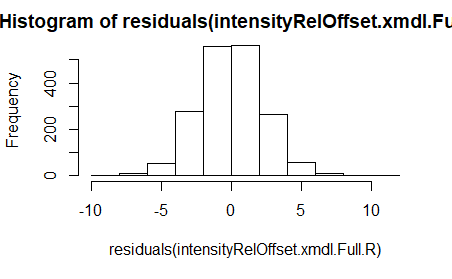

```r
hist(residuals(intensityRelOffset.xmdl.Full.R))
```

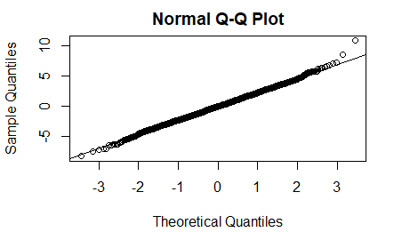

```r
qqnorm(residuals(intensityRelOffset.xmdl.Full.R)); qqline(residuals(intensityRelOffset.xmdl.Full.R))
```

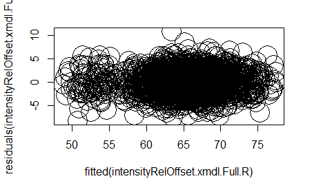

```r
plot(fitted(intensityRelOffset.xmdl.Full.R),residuals(intensityRelOffset.xmdl.Full.R), cex = 4)
```

##### 5.3.3.2.3 Summary of model

```r
summary(intensityRelOffset.xmdl.Full.R)
```

```
Linear mixed model fit by REML. t-tests use Satterthwaite's method [
lmerModLmerTest]
Formula:
intensityOffset ~ voiced.unvoiced_c + singGem_c + sex_c + vowelLength_c +
    syllType_c + place_c + (voiced.unvoiced_c + singGem_c + vowelLength_c +
    syllType_c + place_c || speaker) + (1 | wordTarget)
   Data: geminationVOT
Control:
lmerControl(optimizer = "bobyqa", optCtrl = list(maxfun = 1e+05))

REML criterion at convergence: 8534.2

Scaled residuals:
    Min      1Q  Median      3Q     Max
-3.4273 -0.6503 -0.0024  0.6486  4.5428

Random effects:
 Groups     Name              Variance Std.Dev.
 wordTarget (Intercept)        0.6806  0.8250
 speaker    place_c            0.4863  0.6974
 speaker.1  syllType_c         1.2283  1.1083
 speaker.2  vowelLength_c      0.3749  0.6123
 speaker.3  singGem_c          0.2322  0.4819
 speaker.4  voiced.unvoiced_c  1.0280  1.0139
 speaker.5  (Intercept)       16.2430  4.0303
 Residual                      5.7548  2.3989
Number of obs: 1793, groups:  wordTarget, 98; speaker, 20

Fixed effects:
                  Estimate Std. Error      df t value Pr(>|t|)
(Intercept)        64.5944     0.9193 19.1496  70.265  < 2e-16 ***
voiced.unvoiced_c   1.2817     0.3347 45.3702   3.830 0.000391 ***
singGem_c          -0.7361     0.2509 57.9888  -2.933 0.004794 **
sex_c              -4.3568     1.8100 17.9928  -2.407 0.027037 *
vowelLength_c      -2.4445     0.2691 55.8602  -9.085 1.34e-12 ***
syllType_c          0.8141     0.3854 47.0427   2.113 0.039969 *
place_c            -1.6463     0.3594 59.2184  -4.581 2.43e-05 ***
---
Signif. codes:  0 ‘***’ 0.001 ‘**’ 0.01 ‘*’ 0.05 ‘.’ 0.1 ‘ ’ 1

Correlation of Fixed Effects:
            (Intr) vcd.n_ sngGm_ sex_c  vwlLn_ syllT_
vocd.nvcd_c  0.027
singGem_c   -0.047 -0.025
sex_c       -0.001  0.000  0.001
vowlLngth_c  0.056 -0.094  0.063  0.000
syllType_c   0.091  0.023 -0.269 -0.001  0.186
place_c      0.096  0.354 -0.010 -0.001 -0.045  0.022
```

#### 5.3.3.3 Figures

The figure presented below, uses the predicted (or fitted) values; these are the values *adjusted* by the statistical model. These take into account the random effects’ structure as well as the fixed effects’ structure.

##### 5.3.3.3.1 Using “predict”

The following code is used to record the predicted (or fitted) values into the same data-frame. This will then be used to plot the results of the model

```r
geminationVOT$fitted_RelIntensityOffset <- predict(lmer(intensityOffset~voiced.unvoiced_c+singGem_c+sex_c+vowelLength_c+syllType_c+place_c+
                                (voiced.unvoiced_c+singGem_c+vowelLength_c+syllType_c+place_c||speaker)+(1|wordTarget),
                              data = geminationVOT,na.action=na.exclude,
                              REML=T,
                              control = lmerControl(optimizer = "bobyqa",optCtrl=list(maxfun=1e5)))
)
```

##### 5.3.3.3.2 Plotting the results

We use “ggplot2” to plot the results. This will use the “predicted” (or fitted) values adjusted by our statistical model. The dashed lines *within* the boxplots are the mean values; the median is marked by the horizontal straight lines.

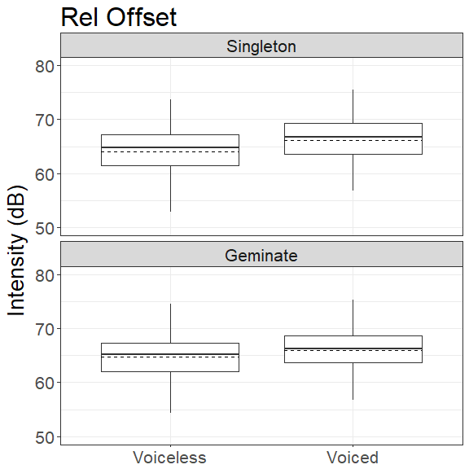

```r
labels <- c(singleton = "Singleton", geminate = "Geminate")
ggIntensityRelOffsetByVoice <- ggplot(geminationVOT, aes(y=fitted_RelIntensityOffset, x=voiced.unvoiced)) +
  geom_boxplot(outlier.colour = "NA",na.rm=TRUE) +
  stat_summary(fun.y = mean, geom = "errorbar", aes(ymax = ..y.., ymin = ..y..),
               width = .75, linetype = "dashed") +
  ylab(expression(paste("Intensity (dB)"))) + labs(title = "Rel Offset") +
  theme_set(theme_bw()) + theme(text=element_text(size=20)) +
  coord_cartesian(ylim = c(50,80)) +
  theme(axis.title.x = element_blank()) + theme(legend.title=element_blank()) +
  scale_x_discrete(breaks=levels(geminationVOT$voiced.unvoiced), labels=c("Voiceless","Voiced")) +
  facet_wrap(~singGem,ncol=1,labeller=labeller(singGem = labels))
ggIntensityRelOffsetByVoice
```

#### 5.3.3.4 Pairwise comparisons

After running our statistical model above, we wanted to evaluate whether the differences observed between “voicing” and “gemination” is statistically significant (or not). We present the means and standard deviations for each of the four-way contrast based on the predicted (or fitted) values.

##### 5.3.3.4.1 Descriptive statistics

The predicted means and SDs of the Intensity at the Offset of the Release phase (RelOffset) are provided below. As can be seen, there are already differences observed related to both “voicing” and “gemination”.

```r
# using "dplyr"
geminationVOT %>% group_by(singGem:voiced.unvoiced) %>% summarise(mean(fitted_RelIntensityOffset), sd(fitted_RelIntensityOffset))
```

| singGem:voiced.unvoiced | mean(fitted_RelIntensityOffset) | sd(fitted_RelIntensityOffset) |
| --- | --- | --- |
| singleton:voiceless | 64.07818 | 4.677952 |
| singleton:voiced | 66.09237 | 4.928769 |
| geminate:voiceless | 64.66630 | 4.748429 |
| geminate:voiced | 65.99241 | 4.705435 |

##### 5.3.3.4.2 Pairwise t-test with FDR corrections

We used the pairwise t-test as available in base R. The input was the predicted (or fitted) values as adjusted by our statistical model. It was not possible to directly use our statistical model’s output to compare models, given that our LMM model was looking at overall change as a main effect rather than as a simple effect’s model. This is why we have used the predicted (or fitted) values as adjusted by our statistical model; the results are the same if we were to use the “actual” results rather than the predicted ones. We used FDR (for False Discovery Rate) correction for multiple comparisons as this allowed for correcting for bias in the differences in doing multiple comparisons.

```r
pairwise.t.test(geminationVOT$fitted_RelIntensityOffset, geminationVOT$singGem:geminationVOT$voiced.unvoiced, p.adj = "fdr")
```

```
    Pairwise comparisons using t tests with pooled SD

data:  geminationVOT$fitted_RelIntensityOffset and geminationVOT$singGem:geminationVOT$voiced.unvoiced

                   singleton:voiceless singleton:voiced
singleton:voiced   2.7e-08             -
geminate:voiceless 0.12                2.0e-05
geminate:voiced    2.7e-08             0.73
                   geminate:voiceless
singleton:voiced   -
geminate:voiceless -
geminate:voiced    2.2e-05

P value adjustment method: fdr
```

### 5.3.4 At the onset of the following vowel

#### 5.3.4.1 Model specification

We run three models. For model comparisons, we are required to use Maximum Likelihood (ML) on both Optimal and Null models (by adding REML=F). Then we run a second Optimal models with Restricted Maximum Likelihood (REML), to obtain the coefficients (by adding REML=T)

##### 5.3.4.1.1 Optimal model (ML)

```r
intensityV2Onset.xmdl.Full.M <- lmer(intensityOnset~voiced.unvoiced_c+singGem_c+sex_c+vowelLength_c+syllType_c+place_c+
                                (voiced.unvoiced_c+singGem_c+vowelLength_c+syllType_c+place_c||speaker)+(1|wordTarget),
                              data = geminationV2,na.action=na.exclude,
                              REML=F,
                              control = lmerControl(optimizer = "bobyqa",optCtrl=list(maxfun=1e5)))
```

##### 5.3.4.1.2 Optimal model (REML)

```r
intensityV2Onset.xmdl.Full.R <- lmer(intensityOnset~voiced.unvoiced_c+singGem_c+sex_c+vowelLength_c+syllType_c+place_c+
                                (voiced.unvoiced_c+singGem_c+vowelLength_c+syllType_c+place_c||speaker)+(1|wordTarget),
                              data = geminationV2,na.action=na.exclude,
                              REML=T,
                              control = lmerControl(optimizer = "bobyqa",optCtrl=list(maxfun=1e5)))
```

##### 5.3.4.1.3 Null model (ML)

```r
intensityV2Onset.xmdl.Null.M <- lmer(intensityOnset~1+
                                (voiced.unvoiced_c+singGem_c+vowelLength_c+syllType_c+place_c||speaker)+(1|wordTarget),
                              data = geminationV2,na.action=na.exclude,
                              REML=F,
                              control = lmerControl(optimizer = "bobyqa",optCtrl=list(maxfun=1e5)))
```

#### 5.3.4.2 Results of our model

##### 5.3.4.2.1 Model comparisons

```r
anova(intensityV2Onset.xmdl.Null.M,intensityV2Onset.xmdl.Full.M)
```

```
Data: geminationV2
Models:
intensityV2Onset.xmdl.Null.M: intensityOnset ~ 1 + (voiced.unvoiced_c + singGem_c + vowelLength_c +
intensityV2Onset.xmdl.Null.M:     syllType_c + place_c || speaker) + (1 | wordTarget)
intensityV2Onset.xmdl.Full.M: intensityOnset ~ voiced.unvoiced_c + singGem_c + sex_c + vowelLength_c +
intensityV2Onset.xmdl.Full.M:     syllType_c + place_c + (voiced.unvoiced_c + singGem_c + vowelLength_c +
intensityV2Onset.xmdl.Full.M:     syllType_c + place_c || speaker) + (1 | wordTarget)
                             Df    AIC    BIC  logLik deviance  Chisq
intensityV2Onset.xmdl.Null.M  9 8549.7 8599.1 -4265.9   8531.7
intensityV2Onset.xmdl.Full.M 15 8468.1 8550.5 -4219.1   8438.1 93.575
                             Chi Df Pr(>Chisq)
intensityV2Onset.xmdl.Null.M
intensityV2Onset.xmdl.Full.M      6  < 2.2e-16 ***
---
Signif. codes:  0 ‘***’ 0.001 ‘**’ 0.01 ‘*’ 0.05 ‘.’ 0.1 ‘ ’ 1
```

As can be seen, our optimal model improved the model fit.

##### 5.3.4.2.2 Residuals

We inspect our model below, by looking at the residuals. There are minor deviations observed, due to the nature of our data.

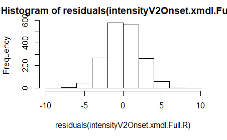

```r
hist(residuals(intensityV2Onset.xmdl.Full.R))
```

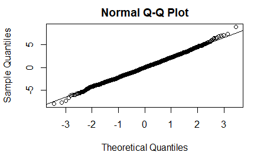

```r
qqnorm(residuals(intensityV2Onset.xmdl.Full.R)); qqline(residuals(intensityV2Onset.xmdl.Full.R))
```

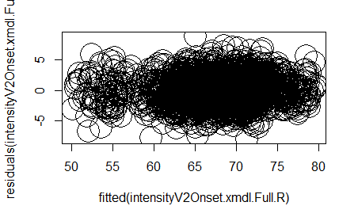

```r
plot(fitted(intensityV2Onset.xmdl.Full.R),residuals(intensityV2Onset.xmdl.Full.R), cex = 4)
```

##### 5.3.4.2.3 Summary of model

```r
summary(intensityV2Onset.xmdl.Full.R)
```

```
Linear mixed model fit by REML. t-tests use Satterthwaite's method [
lmerModLmerTest]
Formula:
intensityOnset ~ voiced.unvoiced_c + singGem_c + sex_c + vowelLength_c +
    syllType_c + place_c + (voiced.unvoiced_c + singGem_c + vowelLength_c +
    syllType_c + place_c || speaker) + (1 | wordTarget)
   Data: geminationV2
Control:
lmerControl(optimizer = "bobyqa", optCtrl = list(maxfun = 1e+05))

REML criterion at convergence: 8435.8

Scaled residuals:
    Min      1Q  Median      3Q     Max
-3.4796 -0.6459 -0.0052  0.6282  3.8583

Random effects:
 Groups     Name              Variance Std.Dev.
 wordTarget (Intercept)        0.6972  0.8350
 speaker    place_c            0.5136  0.7166
 speaker.1  syllType_c         1.4878  1.2198
 speaker.2  vowelLength_c      0.1494  0.3866
 speaker.3  singGem_c          0.3525  0.5937
 speaker.4  voiced.unvoiced_c  1.6696  1.2921
 speaker.5  (Intercept)       17.4143  4.1730
 Residual                      5.3894  2.3215
Number of obs: 1793, groups:  wordTarget, 98; speaker, 20

Fixed effects:
                  Estimate Std. Error      df t value Pr(>|t|)
(Intercept)        67.1891     0.9506 19.0806  70.684  < 2e-16 ***
voiced.unvoiced_c   0.7896     0.3793 37.7429   2.082 0.044213 *
singGem_c          -0.4436     0.2623 56.6391  -1.691 0.096298 .
sex_c              -6.0558     1.8732 17.9905  -3.233 0.004619 **
vowelLength_c      -2.4906     0.2468 65.2472 -10.093  5.9e-15 ***
syllType_c          0.9921     0.4015 44.9078   2.471 0.017328 *
place_c            -1.4757     0.3607 59.4414  -4.091 0.000131 ***
---
Signif. codes:  0 ‘***’ 0.001 ‘**’ 0.01 ‘*’ 0.05 ‘.’ 0.1 ‘ ’ 1

Correlation of Fixed Effects:
            (Intr) vcd.n_ sngGm_ sex_c  vwlLn_ syllT_
vocd.nvcd_c  0.023
singGem_c   -0.043 -0.021
sex_c        0.000  0.000  0.000
vowlLngth_c  0.058 -0.090  0.065  0.000
syllType_c   0.084  0.019 -0.246 -0.001  0.194
place_c      0.092  0.310 -0.010 -0.001 -0.049  0.021
```

#### 5.3.4.3 Figures

The figure presented below, uses the predicted (or fitted) values; these are the values *adjusted* by the statistical model. These take into account the random effects’ structure as well as the fixed effects’ structure.

##### 5.3.4.3.1 Using “predict”

The following code is used to record the predicted (or fitted) values into the same data-frame. This will then be used to plot the results of the model

```r
geminationV2$fitted_V2IntensityOnset <- predict(lmer(intensityOnset~voiced.unvoiced_c+singGem_c+sex_c+vowelLength_c+syllType_c+place_c+
                                (voiced.unvoiced_c+singGem_c+vowelLength_c+syllType_c+place_c||speaker)+(1|wordTarget),
                              data = geminationV2,na.action=na.exclude,
                              REML=T,
                              control = lmerControl(optimizer = "bobyqa",optCtrl=list(maxfun=1e5)))
)
```

##### 5.3.4.3.2 Plotting the results

We use “ggplot2” to plot the results. This will use the “predicted” (or fitted) values adjusted by our statistical model. The dashed lines *within* the boxplots are the mean values; the median is marked by the horizontal straight lines.

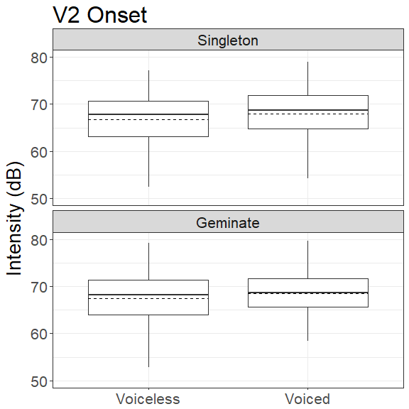

```r
labels <- c(singleton = "Singleton", geminate = "Geminate")
ggIntensityV2OnsetByVoice <- ggplot(geminationV2, aes(y=fitted_V2IntensityOnset, x=voiced.unvoiced)) +
  geom_boxplot(outlier.colour = "NA",na.rm=TRUE) +
  stat_summary(fun.y = mean, geom = "errorbar", aes(ymax = ..y.., ymin = ..y..),
               width = .75, linetype = "dashed") +
  ylab(expression(paste("Intensity (dB)"))) + labs(title = "V2 Onset") +
  theme_set(theme_bw()) + theme(text=element_text(size=20)) +
  coord_cartesian(ylim = c(50,80)) +
  theme(axis.title.x = element_blank()) + theme(legend.title=element_blank()) +
  scale_x_discrete(breaks=levels(geminationV2$voiced.unvoiced), labels=c("Voiceless","Voiced")) +
  facet_wrap(~singGem,ncol=1,labeller=labeller(singGem = labels))
ggIntensityV2OnsetByVoice
```

#### 5.3.4.4 Pairwise comparisons

After running our statistical model above, we wanted to evaluate whether the differences observed between “voicing” and “gemination” is statistically significant (or not). We present the means and standard deviations for each of the four-way contrast based on the predicted (or fitted) values.

##### 5.3.4.4.1 Descriptive statistics

The predicted means and SDs of the Intensity at the Onset of the following vowel (V2Onset) are provided below. As can be seen, there are already differences observed related to both “voicing” and “gemination”.

```r
# using "dplyr"
geminationV2 %>% group_by(singGem:voiced.unvoiced) %>% summarise(mean(fitted_V2IntensityOnset), sd(fitted_V2IntensityOnset))
```

| singGem:voiced.unvoiced | mean(fitted_V2IntensityOnset) | sd(fitted_V2IntensityOnset) |
| --- | --- | --- |
| singleton:voiceless | 66.74463 | 5.266363 |
| singleton:voiced | 68.01185 | 5.421603 |
| geminate:voiceless | 67.46293 | 5.367887 |
| geminate:voiced | 68.43291 | 5.192073 |

##### 5.3.4.4.2 Pairwise t-test with FDR corrections

We used the pairwise t-test as available in base R. The input was the predicted (or fitted) values as adjusted by our statistical model. It was not possible to directly use our statistical model’s output to compare models, given that our LMM model was looking at overall change as a main effect rather than as a simple effect’s model. This is why we have used the predicted (or fitted) values as adjusted by our statistical model; the results are the same if we were to use the “actual” results rather than the predicted ones. We used FDR (for False Discovery Rate) correction for multiple comparisons as this allowed for correcting for bias in the differences in doing multiple comparisons.

```r
pairwise.t.test(geminationV2$fitted_V2IntensityOnset, geminationV2$singGem:geminationV2$voiced.unvoiced, p.adj = "fdr")
```

```
    Pairwise comparisons using t tests with pooled SD

data:  geminationV2$fitted_V2IntensityOnset and geminationV2$singGem:geminationV2$voiced.unvoiced

                   singleton:voiceless singleton:voiced
singleton:voiced   0.0031              -
geminate:voiceless 0.1039              0.1504
geminate:voiced    3e-05               0.2000
                   geminate:voiceless
singleton:voiced   -
geminate:voiceless -
geminate:voiced    0.0087

P value adjustment method: fdr
```

## 5.4 Fundamental frequency (Hz)

Within the fundamental frequency *f*0, we have computed *f*0 at two locations: At the Offset of the preceding vowel (V1Offset) and at the Onset of the following vowel (V2Offset).

### 5.4.1 At the offset of the preceding vowel

#### 5.4.1.1 Model specification

We run three models. For model comparisons, we are required to use Maximum Likelihood (ML) on both Optimal and Null models (by adding REML=F). Then we run a second Optimal models with Restricted Maximum Likelihood (REML), to obtain the coefficients (by adding REML=T)

##### 5.4.1.1.1 Optimal model (ML)

```r
f0V1Offset.xmdl.Full.M <- lmer(f0Offset~voiced.unvoiced_c+singGem_c+sex_c+vowelLength_c+syllType_c+place_c+
                                (voiced.unvoiced_c+singGem_c+vowelLength_c+syllType_c+place_c||speaker)+(1|wordTarget),
                              data = geminationV1,na.action=na.exclude,
                              REML=F,
                              control = lmerControl(optimizer = "bobyqa",optCtrl=list(maxfun=1e5)))
```

##### 5.4.1.1.2 Optimal model (REML)

```r
f0V1Offset.xmdl.Full.R <- lmer(f0Offset~voiced.unvoiced_c+singGem_c+sex_c+vowelLength_c+syllType_c+place_c+
                                (voiced.unvoiced_c+singGem_c+vowelLength_c+syllType_c+place_c||speaker)+(1|wordTarget),
                              data = geminationV1,na.action=na.exclude,
                              REML=T,
                              control = lmerControl(optimizer = "bobyqa",optCtrl=list(maxfun=1e5)))
```

##### 5.4.1.1.3 Null model (ML)

```r
f0V1Offset.xmdl.Null.M <- lmer(f0Offset~1+
                                (voiced.unvoiced_c+singGem_c+vowelLength_c+syllType_c+place_c||speaker)+(1|wordTarget),
                              data = geminationV1,na.action=na.exclude,
                              REML=F,
                              control = lmerControl(optimizer = "bobyqa",optCtrl=list(maxfun=1e5)))
```

#### 5.4.1.2 Results of our model

##### 5.4.1.2.1 Model comparisons

```r
anova(f0V1Offset.xmdl.Null.M,f0V1Offset.xmdl.Full.M)
```

```
Data: geminationV1
Models:
f0V1Offset.xmdl.Null.M: f0Offset ~ 1 + (voiced.unvoiced_c + singGem_c + vowelLength_c +
f0V1Offset.xmdl.Null.M:     syllType_c + place_c || speaker) + (1 | wordTarget)
f0V1Offset.xmdl.Full.M: f0Offset ~ voiced.unvoiced_c + singGem_c + sex_c + vowelLength_c +
f0V1Offset.xmdl.Full.M:     syllType_c + place_c + (voiced.unvoiced_c + singGem_c + vowelLength_c +
f0V1Offset.xmdl.Full.M:     syllType_c + place_c || speaker) + (1 | wordTarget)
                       Df   AIC   BIC  logLik deviance  Chisq Chi Df
f0V1Offset.xmdl.Null.M  9 14274 14324 -7128.1    14256
f0V1Offset.xmdl.Full.M 15 14173 14256 -7071.7    14143 112.75      6
                       Pr(>Chisq)
f0V1Offset.xmdl.Null.M
f0V1Offset.xmdl.Full.M  < 2.2e-16 ***
---
Signif. codes:  0 ‘***’ 0.001 ‘**’ 0.01 ‘*’ 0.05 ‘.’ 0.1 ‘ ’ 1
```

As can be seen, our optimal model improved the model fit.

##### 5.4.1.2.2 Residuals

We inspect our model below, by looking at the residuals. There are minor deviations observed, due to the nature of our data.

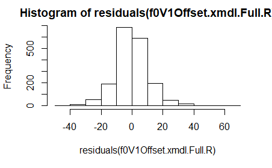

```r
hist(residuals(f0V1Offset.xmdl.Full.R))
```

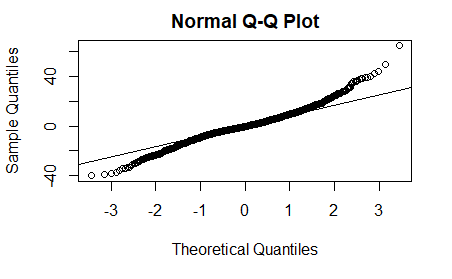

```r
qqnorm(residuals(f0V1Offset.xmdl.Full.R)); qqline(residuals(f0V1Offset.xmdl.Full.R))
```

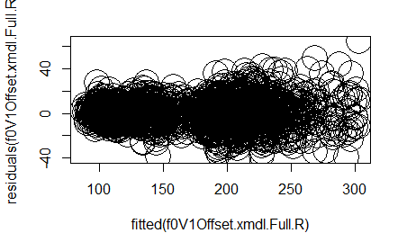

```r
plot(fitted(f0V1Offset.xmdl.Full.R),residuals(f0V1Offset.xmdl.Full.R), cex = 4)
```

##### 5.4.1.2.3 Summary of model

```r
summary(f0V1Offset.xmdl.Full.R)
```

```
Linear mixed model fit by REML. t-tests use Satterthwaite's method [
lmerModLmerTest]
Formula:
f0Offset ~ voiced.unvoiced_c + singGem_c + sex_c + vowelLength_c +
    syllType_c + place_c + (voiced.unvoiced_c + singGem_c + vowelLength_c +
    syllType_c + place_c || speaker) + (1 | wordTarget)
   Data: geminationV1
Control:
lmerControl(optimizer = "bobyqa", optCtrl = list(maxfun = 1e+05))

REML criterion at convergence: 14118.1

Scaled residuals:
    Min      1Q  Median      3Q     Max
-3.5284 -0.4831 -0.0411  0.5022  5.6981

Random effects:
 Groups     Name              Variance Std.Dev.
 wordTarget (Intercept)        13.704   3.702
 speaker    place_c             0.000   0.000
 speaker.1  syllType_c         72.720   8.528
 speaker.2  vowelLength_c     105.182  10.256
 speaker.3  singGem_c           5.242   2.290
 speaker.4  voiced.unvoiced_c  14.319   3.784
 speaker.5  (Intercept)       435.365  20.865
 Residual                     128.927  11.355
Number of obs: 1793, groups:  wordTarget, 98; speaker, 20

Fixed effects:
                  Estimate Std. Error      df t value Pr(>|t|)
(Intercept)        161.417      4.739  18.894  34.064  < 2e-16 ***
voiced.unvoiced_c   -4.657      1.407  55.014  -3.310  0.00165 **
singGem_c            4.557      1.155  54.227   3.946  0.00023 ***
sex_c               89.850      9.362  17.997   9.597 1.68e-08 ***
vowelLength_c      -12.207      2.526  24.199  -4.833 6.22e-05 ***
syllType_c         -21.748      2.335  30.551  -9.313 1.96e-10 ***
place_c              0.401      1.476  91.648   0.272  0.78649
---
Signif. codes:  0 ‘***’ 0.001 ‘**’ 0.01 ‘*’ 0.05 ‘.’ 0.1 ‘ ’ 1

Correlation of Fixed Effects:
            (Intr) vcd.n_ sngGm_ sex_c  vwlLn_ syllT_
vocd.nvcd_c  0.026
singGem_c   -0.041 -0.027
sex_c        0.000  0.001  0.001
vowlLngth_c  0.024 -0.050  0.030  0.000
syllType_c   0.061  0.019 -0.201 -0.001  0.068
place_c      0.094  0.427 -0.011  0.000 -0.024  0.019
```

#### 5.4.1.3 Figures

The figure presented below, uses the predicted (or fitted) values; these are the values *adjusted* by the statistical model. These take into account the random effects’ structure as well as the fixed effects’ structure.

##### 5.4.1.3.1 Using “predict”

The following code is used to record the predicted (or fitted) values into the same data-frame. This will then be used to plot the results of the model

```r
geminationV1$fitted_V1F0Offset <- predict(lmer(f0Offset~voiced.unvoiced_c+singGem_c+sex_c+vowelLength_c+syllType_c+place_c+
                                (voiced.unvoiced_c+singGem_c+vowelLength_c+syllType_c+place_c||speaker)+(1|wordTarget),
                              data = geminationV1,na.action=na.exclude,
                              REML=T,
                              control = lmerControl(optimizer = "bobyqa",optCtrl=list(maxfun=1e5)))
)
```

##### 5.4.1.3.2 Plotting the results

We use “ggplot2” to plot the results. This will use the “predicted” (or fitted) values adjusted by our statistical model. The dashed lines *within* the boxplots are the mean values; the median is marked by the horizontal straight lines.

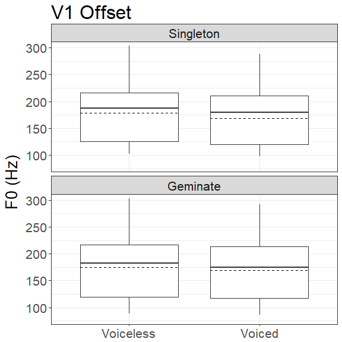

```r
labels <- c(singleton = "Singleton", geminate = "Geminate")
ggF0V1OffsetByVoice <- ggplot(geminationV1, aes(y=fitted_V1F0Offset, x=voiced.unvoiced)) +
  geom_boxplot(outlier.colour = "NA",na.rm=TRUE) +
  stat_summary(fun.y = mean, geom = "errorbar", aes(ymax = ..y.., ymin = ..y..),
               width = .75, linetype = "dashed") +
  ylab(expression(paste("F0 (Hz)"))) + labs(title = "V1 Offset") +
  theme_set(theme_bw()) + theme(text=element_text(size=20)) +
  coord_cartesian(ylim = c(80,300)) +
  theme(axis.title.x = element_blank()) + theme(legend.title=element_blank()) +
  scale_x_discrete(breaks=levels(geminationV1$voiced.unvoiced), labels=c("Voiceless","Voiced")) +
  facet_wrap(~singGem,ncol=1,labeller=labeller(singGem = labels))
ggF0V1OffsetByVoice
```

#### 5.4.1.4 Pairwise comparisons

After running our statistical model above, we wanted to evaluate whether the differences observed between “voicing” and “gemination” is statistically significant (or not). We present the means and standard deviations for each of the four-way contrast based on the predicted (or fitted) values.

##### 5.4.1.4.1 Descriptive statistics

The predicted means and SDs of the F0 at the Offset of the preceding vowel (V1Offset) are provided below. As can be seen, there are already differences observed related to both “voicing” and “gemination”.

```r
# using "dplyr"
geminationV1 %>% group_by(singGem:voiced.unvoiced) %>% summarise(mean(fitted_V1F0Offset), sd(fitted_V1F0Offset))
```

| singGem:voiced.unvoiced | mean(fitted_V1F0Offset) | sd(fitted_V1F0Offset) |
| --- | --- | --- |
| singleton:voiceless | 177.9228 | 54.38252 |
| singleton:voiced | 168.9189 | 51.69264 |
| geminate:voiceless | 174.3314 | 54.67428 |
| geminate:voiced | 169.1813 | 52.75893 |

##### 5.4.1.4.2 Pairwise t-test with FDR corrections

We used the pairwise t-test as available in base R. The input was the predicted (or fitted) values as adjusted by our statistical model. It was not possible to directly use our statistical model’s output to compare models, given that our LMM model was looking at overall change as a main effect rather than as a simple effect’s model. This is why we have used the predicted (or fitted) values as adjusted by our statistical model; the results are the same if we were to use the “actual” results rather than the predicted ones. We used FDR (for False Discovery Rate) correction for multiple comparisons as this allowed for correcting for bias in the differences in doing multiple comparisons.

```r
pairwise.t.test(geminationV1$fitted_V1F0Offset, geminationV1$singGem:geminationV1$voiced.unvoiced, p.adj = "fdr")
```

```
    Pairwise comparisons using t tests with pooled SD

data:  geminationV1$fitted_V1F0Offset and geminationV1$singGem:geminationV1$voiced.unvoiced

                   singleton:voiceless singleton:voiced
singleton:voiced   0.06                -
geminate:voiceless 0.44                0.20
geminate:voiced    0.06                0.94
                   geminate:voiceless
singleton:voiced   -
geminate:voiceless -
geminate:voiced    0.20

P value adjustment method: fdr
```

### 5.4.2 At the onset of the following vowel

#### 5.4.2.1 Model specification

We run three models. For model comparisons, we are required to use Maximum Likelihood (ML) on both Optimal and Null models (by adding REML=F). Then we run a second Optimal models with Restricted Maximum Likelihood (REML), to obtain the coefficients (by adding REML=T)

##### 5.4.2.1.1 Optimal model (ML)

```r
f0V2Onset.xmdl.Full.M <- lmer(f0Onset~voiced.unvoiced_c+singGem_c+sex_c+vowelLength_c+syllType_c+place_c+
                                (voiced.unvoiced_c+singGem_c+vowelLength_c+syllType_c+place_c||speaker)+(1|wordTarget),
                              data = geminationV2,na.action=na.exclude,
                              REML=F,
                              control = lmerControl(optimizer = "bobyqa",optCtrl=list(maxfun=1e5)))
```

##### 5.4.2.1.2 Optimal model (REML)

```r
f0V2Onset.xmdl.Full.R <- lmer(f0Onset~voiced.unvoiced_c+singGem_c+sex_c+vowelLength_c+syllType_c+place_c+
                                (voiced.unvoiced_c+singGem_c+vowelLength_c+syllType_c+place_c||speaker)+(1|wordTarget),
                              data = geminationV2,na.action=na.exclude,
                              REML=T,
                              control = lmerControl(optimizer = "bobyqa",optCtrl=list(maxfun=1e5)))
```

##### 5.4.2.1.3 Null model (ML)

```r
f0V2Onset.xmdl.Null.M <- lmer(f0Onset~1+
                                (voiced.unvoiced_c+singGem_c+vowelLength_c+syllType_c+place_c||speaker)+(1|wordTarget),
                              data = geminationV2,na.action=na.exclude,
                              REML=F,
                              control = lmerControl(optimizer = "bobyqa",optCtrl=list(maxfun=1e5)))
```

#### 5.4.2.2 Results of our model

##### 5.4.2.2.1 Model comparisons

```r
anova(f0V2Onset.xmdl.Null.M,f0V2Onset.xmdl.Full.M)
```

```
Data: geminationV2
Models:
f0V2Onset.xmdl.Null.M: f0Onset ~ 1 + (voiced.unvoiced_c + singGem_c + vowelLength_c +
f0V2Onset.xmdl.Null.M:     syllType_c + place_c || speaker) + (1 | wordTarget)
f0V2Onset.xmdl.Full.M: f0Onset ~ voiced.unvoiced_c + singGem_c + sex_c + vowelLength_c +
f0V2Onset.xmdl.Full.M:     syllType_c + place_c + (voiced.unvoiced_c + singGem_c + vowelLength_c +
f0V2Onset.xmdl.Full.M:     syllType_c + place_c || speaker) + (1 | wordTarget)
                      Df   AIC   BIC  logLik deviance  Chisq Chi Df
f0V2Onset.xmdl.Null.M  9 14956 15006 -7469.2    14938
f0V2Onset.xmdl.Full.M 15 14898 14980 -7433.8    14868 70.926      6
                      Pr(>Chisq)
f0V2Onset.xmdl.Null.M
f0V2Onset.xmdl.Full.M   2.64e-13 ***
---
Signif. codes:  0 ‘***’ 0.001 ‘**’ 0.01 ‘*’ 0.05 ‘.’ 0.1 ‘ ’ 1
```

As can be seen, our optimal model improved the model fit.

##### 5.4.2.2.2 Residuals

We inspect our model below, by looking at the residuals. There are minor deviations observed, due to the nature of our data.

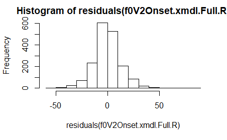

```r
hist(residuals(f0V2Onset.xmdl.Full.R))
```

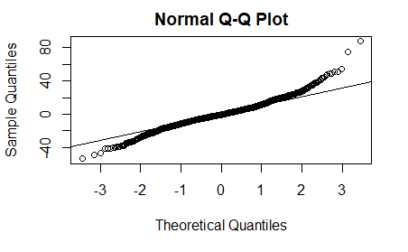

```r
qqnorm(residuals(f0V2Onset.xmdl.Full.R)); qqline(residuals(f0V2Onset.xmdl.Full.R))
```

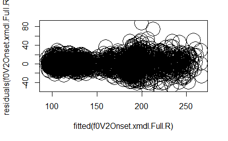

```r
plot(fitted(f0V2Onset.xmdl.Full.R),residuals(f0V2Onset.xmdl.Full.R), cex = 4)
```

##### 5.4.2.2.3 Summary of model

```r
summary(f0V2Onset.xmdl.Full.R)
```

```
Linear mixed model fit by REML. t-tests use Satterthwaite's method [
lmerModLmerTest]
Formula:
f0Onset ~ voiced.unvoiced_c + singGem_c + sex_c + vowelLength_c +
    syllType_c + place_c + (voiced.unvoiced_c + singGem_c + vowelLength_c +
    syllType_c + place_c || speaker) + (1 | wordTarget)
   Data: geminationV2
Control:
lmerControl(optimizer = "bobyqa", optCtrl = list(maxfun = 1e+05))

REML criterion at convergence: 14840.7

Scaled residuals:
    Min      1Q  Median      3Q     Max
-3.8461 -0.5214 -0.0433  0.4939  6.3033

Random effects:
 Groups     Name              Variance Std.Dev.
 wordTarget (Intercept)        19.61    4.429
 speaker    place_c            14.50    3.807
 speaker.1  syllType_c        206.14   14.358
 speaker.2  vowelLength_c      28.80    5.367
 speaker.3  singGem_c          16.04    4.005
 speaker.4  voiced.unvoiced_c  28.51    5.339
 speaker.5  (Intercept)       364.99   19.105
 Residual                     194.22   13.936
Number of obs: 1793, groups:  wordTarget, 98; speaker, 20

Fixed effects:
                  Estimate Std. Error      df t value Pr(>|t|)
(Intercept)        166.589      4.388  19.466  37.968  < 2e-16 ***
voiced.unvoiced_c   -4.001      1.807  44.099  -2.213 0.032089 *
singGem_c           -3.419      1.538  46.068  -2.223 0.031150 *
sex_c               86.824      8.605  18.005  10.090 7.75e-09 ***
vowelLength_c       -3.551      1.753  39.840  -2.026 0.049511 *
syllType_c          15.306      3.599  25.112   4.252 0.000257 ***
place_c              3.116      1.977  57.301   1.576 0.120614
---
Signif. codes:  0 ‘***’ 0.001 ‘**’ 0.01 ‘*’ 0.05 ‘.’ 0.1 ‘ ’ 1

Correlation of Fixed Effects:
            (Intr) vcd.n_ sngGm_ sex_c  vwlLn_ syllT_
vocd.nvcd_c  0.032
singGem_c   -0.049 -0.023
sex_c       -0.001  0.000  0.001
vowlLngth_c  0.054 -0.081  0.048 -0.001
syllType_c   0.062  0.014 -0.143 -0.001  0.093
place_c      0.111  0.362 -0.009 -0.001 -0.039  0.013
```

#### 5.4.2.3 Figures

The figure presented below, uses the predicted (or fitted) values; these are the values *adjusted* by the statistical model. These take into account the random effects’ structure as well as the fixed effects’ structure.

##### 5.4.2.3.1 Using “predict”

The following code is used to record the predicted (or fitted) values into the same data-frame. This will then be used to plot the results of the model

```r
geminationV2$fitted_V2F0Onset <- predict(lmer(f0Onset~voiced.unvoiced_c+singGem_c+sex_c+vowelLength_c+syllType_c+place_c+
                                (voiced.unvoiced_c+singGem_c+vowelLength_c+syllType_c+place_c||speaker)+(1|wordTarget),
                              data = geminationV2,na.action=na.exclude,
                              REML=T,
                              control = lmerControl(optimizer = "bobyqa",optCtrl=list(maxfun=1e5)))
)
```

##### 5.4.2.3.2 Plotting the results

We use “ggplot2” to plot the results. This will use the “predicted” (or fitted) values adjusted by our statistical model. The dashed lines *within* the boxplots are the mean values; the median is marked by the horizontal straight lines.

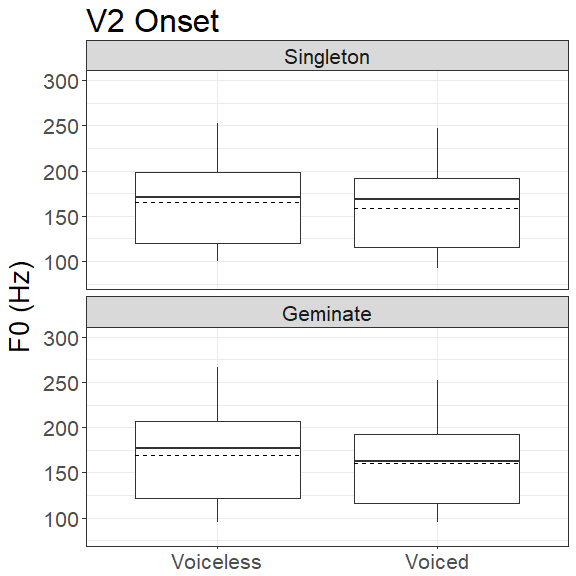

```r
labels <- c(singleton = "Singleton", geminate = "Geminate")
ggF0V2OnsetByVoice <- ggplot(geminationV2, aes(y=fitted_V2F0Onset, x=voiced.unvoiced)) +
  geom_boxplot(outlier.colour = "NA",na.rm=TRUE) +
  stat_summary(fun.y = mean, geom = "errorbar", aes(ymax = ..y.., ymin = ..y..),
               width = .75, linetype = "dashed") +
  ylab(expression(paste("F0 (Hz)"))) + labs(title = "V2 Onset") +
  theme_set(theme_bw()) + theme(text=element_text(size=20)) +
  coord_cartesian(ylim = c(80,300)) +
  theme(axis.title.x = element_blank()) + theme(legend.title=element_blank()) +
  scale_x_discrete(breaks=levels(geminationV2$voiced.unvoiced), labels=c("Voiceless","Voiced")) +
  facet_wrap(~singGem,ncol=1,labeller=labeller(singGem = labels))
ggF0V2OnsetByVoice
```

#### 5.4.2.4 Pairwise comparisons

After running our statistical model above, we wanted to evaluate whether the differences observed between “voicing” and “gemination” is statistically significant (or not). We present the means and standard deviations for each of the four-way contrast based on the predicted (or fitted) values.

##### 5.4.2.4.1 Descriptive statistics

The predicted means and SDs of the F0 at the Onset of the following vowel (V2Onset) are provided below. As can be seen, there are already differences observed related to both “voicing” and “gemination”.

```r
# using "dplyr"
geminationV2 %>% group_by(singGem:voiced.unvoiced) %>% summarise(mean(fitted_V2F0Onset), sd(fitted_V2F0Onset))
```

| singGem:voiced.unvoiced | mean(fitted_V2F0Onset) | sd(fitted_V2F0Onset) |
| --- | --- | --- |
| singleton:voiceless | 165.4504 | 45.46244 |
| singleton:voiced | 158.4952 | 43.39427 |
| geminate:voiceless | 168.8071 | 48.86393 |
| geminate:voiced | 160.0778 | 45.85889 |

##### 5.4.2.4.2 Pairwise t-test with FDR corrections

We used the pairwise t-test as available in base R. The input was the predicted (or fitted) values as adjusted by our statistical model. It was not possible to directly use our statistical model’s output to compare models, given that our LMM model was looking at overall change as a main effect rather than as a simple effect’s model. This is why we have used the predicted (or fitted) values as adjusted by our statistical model; the results are the same if we were to use the “actual” results rather than the predicted ones. We used FDR (for False Discovery Rate) correction for multiple comparisons as this allowed for correcting for bias in the differences in doing multiple comparisons.

```r
pairwise.t.test(geminationV2$fitted_V2F0Onset, geminationV2$singGem:geminationV2$voiced.unvoiced, p.adj = "fdr")
```

```
    Pairwise comparisons using t tests with pooled SD

data:  geminationV2$fitted_V2F0Onset and geminationV2$singGem:geminationV2$voiced.unvoiced

                   singleton:voiceless singleton:voiced
singleton:voiced   0.0741              -
geminate:voiceless 0.3912              0.0053
geminate:voiced    0.1380              0.5774
                   geminate:voiceless
singleton:voiced   -
geminate:voiceless -
geminate:voiced    0.0090

P value adjustment method: fdr
```

## 5.5 F1 frequency (Hz)

Within the first formant frequency (F1), we have computed F1 at two locations: At the Offset of the preceding vowel (V1Offset) and at the Onset of the following vowel (V2Offset).

### 5.5.1 At the offset of the preceding vowel

#### 5.5.1.1 Model specification

We run three models. For model comparisons, we are required to use Maximum Likelihood (ML) on both Optimal and Null models (by adding REML=F). Then we run a second Optimal models with Restricted Maximum Likelihood (REML), to obtain the coefficients (by adding REML=T)

##### 5.5.1.1.1 Optimal model (ML)

```r
f1V1Offset.xmdl.Full.M <- lmer(f1Offset~voiced.unvoiced_c+singGem_c+sex_c+vowelLength_c+syllType_c+place_c+
                                (voiced.unvoiced_c+singGem_c+vowelLength_c+syllType_c+place_c||speaker)+(1|wordTarget),
                              data = geminationV1,na.action=na.exclude,
                              REML=F,
                              control = lmerControl(optimizer = "bobyqa",optCtrl=list(maxfun=1e5)))
```

##### 5.5.1.1.2 Optimal model (REML)

```r
f1V1Offset.xmdl.Full.R <- lmer(f1Offset~voiced.unvoiced_c+singGem_c+sex_c+vowelLength_c+syllType_c+place_c+
                                (voiced.unvoiced_c+singGem_c+vowelLength_c+syllType_c+place_c||speaker)+(1|wordTarget),
                              data = geminationV1,na.action=na.exclude,
                              REML=T,
                              control = lmerControl(optimizer = "bobyqa",optCtrl=list(maxfun=1e5)))
```

##### 5.5.1.1.3 Null model (ML)

```r
f1V1Offset.xmdl.Null.M <- lmer(f1Offset~1+
                                (voiced.unvoiced_c+singGem_c+vowelLength_c+syllType_c+place_c||speaker)+(1|wordTarget),
                              data = geminationV1,na.action=na.exclude,
                              REML=F,
                              control = lmerControl(optimizer = "bobyqa",optCtrl=list(maxfun=1e5)))
```

#### 5.5.1.2 Results of our model

##### 5.5.1.2.1 Model comparisons

```r
anova(f1V1Offset.xmdl.Null.M,f1V1Offset.xmdl.Full.M)
```

```
Data: geminationV1
Models:
f1V1Offset.xmdl.Null.M: f1Offset ~ 1 + (voiced.unvoiced_c + singGem_c + vowelLength_c +
f1V1Offset.xmdl.Null.M:     syllType_c + place_c || speaker) + (1 | wordTarget)
f1V1Offset.xmdl.Full.M: f1Offset ~ voiced.unvoiced_c + singGem_c + sex_c + vowelLength_c +
f1V1Offset.xmdl.Full.M:     syllType_c + place_c + (voiced.unvoiced_c + singGem_c + vowelLength_c +
f1V1Offset.xmdl.Full.M:     syllType_c + place_c || speaker) + (1 | wordTarget)
                       Df   AIC   BIC logLik deviance Chisq Chi Df
f1V1Offset.xmdl.Null.M  9 21072 21122 -10527    21054
f1V1Offset.xmdl.Full.M 15 21029 21111 -10500    20999 55.37      6
                       Pr(>Chisq)
f1V1Offset.xmdl.Null.M
f1V1Offset.xmdl.Full.M  3.902e-10 ***
---
Signif. codes:  0 ‘***’ 0.001 ‘**’ 0.01 ‘*’ 0.05 ‘.’ 0.1 ‘ ’ 1
```

As can be seen, our optimal model improved the model fit.

##### 5.5.1.2.2 Residuals

We inspect our model below, by looking at the residuals. There are minor deviations observed, due to the nature of our data.

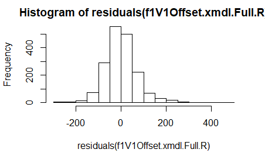

```r
hist(residuals(f1V1Offset.xmdl.Full.R))
```

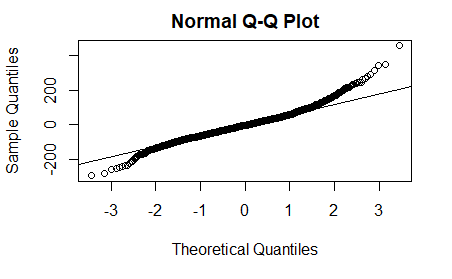

```r
qqnorm(residuals(f1V1Offset.xmdl.Full.R)); qqline(residuals(f1V1Offset.xmdl.Full.R))
```

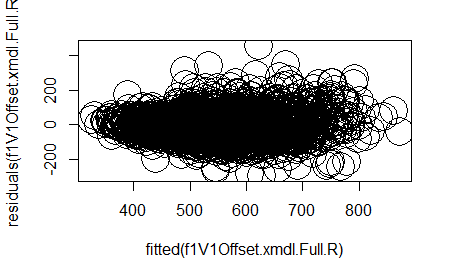

```r
plot(fitted(f1V1Offset.xmdl.Full.R),residuals(f1V1Offset.xmdl.Full.R), cex = 4)
```

##### 5.5.1.2.3 Summary of model

```r
summary(f1V1Offset.xmdl.Full.R)
```

```
Linear mixed model fit by REML. t-tests use Satterthwaite's method [
lmerModLmerTest]
Formula:
f1Offset ~ voiced.unvoiced_c + singGem_c + sex_c + vowelLength_c +
    syllType_c + place_c + (voiced.unvoiced_c + singGem_c + vowelLength_c +
    syllType_c + place_c || speaker) + (1 | wordTarget)
   Data: geminationV1
Control:
lmerControl(optimizer = "bobyqa", optCtrl = list(maxfun = 1e+05))

REML criterion at convergence: 20948.7

Scaled residuals:
    Min      1Q  Median      3Q     Max
-3.8871 -0.5834 -0.0374  0.4792  6.0431

Random effects:
 Groups     Name              Variance Std.Dev.
 wordTarget (Intercept)       2345.9   48.43
 speaker    place_c            656.3   25.62
 speaker.1  syllType_c        2997.7   54.75
 speaker.2  vowelLength_c      874.6   29.57
 speaker.3  singGem_c            0.0    0.00
 speaker.4  voiced.unvoiced_c 1266.7   35.59
 speaker.5  (Intercept)       1678.2   40.97
 Residual                     5780.7   76.03
Number of obs: 1793, groups:  wordTarget, 98; speaker, 20

Fixed effects:
                  Estimate Std. Error      df t value Pr(>|t|)
(Intercept)        500.385     13.113  54.128  38.159  < 2e-16 ***
voiced.unvoiced_c  -57.289     15.005  81.271  -3.818 0.000262 ***
singGem_c           -1.322     11.689  92.445  -0.113 0.910211
sex_c               70.557     19.127  18.080   3.689 0.001669 **
vowelLength_c      -52.440     13.664  84.584  -3.838 0.000239 ***
syllType_c         -85.399     19.557  68.263  -4.367 4.39e-05 ***
place_c            -64.575     17.674  91.021  -3.654 0.000432 ***
---
Signif. codes:  0 ‘***’ 0.001 ‘**’ 0.01 ‘*’ 0.05 ‘.’ 0.1 ‘ ’ 1

Correlation of Fixed Effects:
            (Intr) vcd.n_ sngGm_ sex_c  vwlLn_ syllT_
vocd.nvcd_c  0.114
singGem_c   -0.190 -0.031
sex_c       -0.004  0.000  0.001
vowlLngth_c  0.205 -0.111  0.070 -0.001
syllType_c   0.337  0.026 -0.301 -0.002  0.194
place_c      0.364  0.429 -0.012 -0.003 -0.048  0.023
```

#### 5.5.1.3 Figures

The figure presented below, uses the predicted (or fitted) values; these are the values *adjusted* by the statistical model. These take into account the random effects’ structure as well as the fixed effects’ structure.

##### 5.5.1.3.1 Using “predict”

The following code is used to record the predicted (or fitted) values into the same data-frame. This will then be used to plot the results of the model

```r
geminationV1$fitted_V1F1Offset <- predict(lmer(f1Offset~voiced.unvoiced_c+singGem_c+sex_c+vowelLength_c+syllType_c+place_c+
                                (voiced.unvoiced_c+singGem_c+vowelLength_c+syllType_c+place_c||speaker)+(1|wordTarget),
                              data = geminationV1,na.action=na.exclude,
                              REML=T,
                              control = lmerControl(optimizer = "bobyqa",optCtrl=list(maxfun=1e5)))
)
```

##### 5.5.1.3.2 Plotting the results

We use “ggplot2” to plot the results. This will use the “predicted” (or fitted) values adjusted by our statistical model. The dashed lines *within* the boxplots are the mean values; the median is marked by the horizontal straight lines.

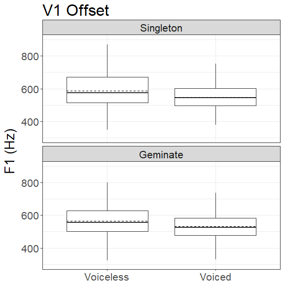

```r
labels <- c(singleton = "Singleton", geminate = "Geminate")
ggF1V1OffsetByVoice <- ggplot(geminationV1, aes(y=fitted_V1F1Offset, x=voiced.unvoiced)) +
  geom_boxplot(outlier.colour = "NA",na.rm=TRUE) +
  stat_summary(fun.y = mean, geom = "errorbar", aes(ymax = ..y.., ymin = ..y..),
               width = .75, linetype = "dashed") +
  ylab(expression(paste("F1 (Hz)"))) + labs(title = "V1 Offset") +
  theme_set(theme_bw()) + theme(text=element_text(size=20)) +
  coord_cartesian(ylim = c(300,900)) +
  theme(axis.title.x = element_blank()) + theme(legend.title=element_blank()) +
  scale_x_discrete(breaks=levels(geminationV1$voiced.unvoiced), labels=c("Voiceless","Voiced")) +
  facet_wrap(~singGem,ncol=1,labeller=labeller(singGem = labels))
ggF1V1OffsetByVoice
```

#### 5.5.1.4 Pairwise comparisons

After running our statistical model above, we wanted to evaluate whether the differences observed between “voicing” and “gemination” is statistically significant (or not). We present the means and standard deviations for each of the four-way contrast based on the predicted (or fitted) values.

##### 5.5.1.4.1 Descriptive statistics

The predicted means and SDs of the F1 at the Offset of the preceding vowel (V1Offset) are provided below. As can be seen, there are already differences observed related to both “voicing” and “gemination”.

```r
# using "dplyr"
geminationV1 %>% group_by(singGem:voiced.unvoiced) %>% summarise(mean(fitted_V1F1Offset), sd(fitted_V1F1Offset))
```

| singGem:voiced.unvoiced | mean(fitted_V1F1Offset) | sd(fitted_V1F1Offset) |
| --- | --- | --- |
| singleton:voiceless | 588.0668 | 106.43925 |
| singleton:voiced | 548.7405 | 74.31595 |
| geminate:voiceless | 564.3050 | 103.32018 |
| geminate:voiced | 531.3425 | 79.04652 |

##### 5.5.1.4.2 Pairwise t-test with FDR corrections

We used the pairwise t-test as available in base R. The input was the predicted (or fitted) values as adjusted by our statistical model. It was not possible to directly use our statistical model’s output to compare models, given that our LMM model was looking at overall change as a main effect rather than as a simple effect’s model. This is why we have used the predicted (or fitted) values as adjusted by our statistical model; the results are the same if we were to use the “actual” results rather than the predicted ones. We used FDR (for False Discovery Rate) correction for multiple comparisons as this allowed for correcting for bias in the differences in doing multiple comparisons.

```r
pairwise.t.test(geminationV1$fitted_V1F1Offset, geminationV1$singGem:geminationV1$voiced.unvoiced, p.adj = "fdr")
```

```
    Pairwise comparisons using t tests with pooled SD

data:  geminationV1$fitted_V1F1Offset and geminationV1$singGem:geminationV1$voiced.unvoiced

                   singleton:voiceless singleton:voiced
singleton:voiced   5e-09               -
geminate:voiceless 0.00055             0.00991
geminate:voiced    < 2e-16             0.00202
                   geminate:voiceless
singleton:voiced   -
geminate:voiceless -
geminate:voiced    2e-08

P value adjustment method: fdr
```

### 5.5.2 At the onset of the following vowel

#### 5.5.2.1 Model specification

We run three models. For model comparisons, we are required to use Maximum Likelihood (ML) on both Optimal and Null models (by adding REML=F). Then we run a second Optimal models with Restricted Maximum Likelihood (REML), to obtain the coefficients (by adding REML=T)

##### 5.5.2.1.1 Optimal model (ML)

```r
f1V2Onset.xmdl.Full.M <- lmer(f1Onset~voiced.unvoiced_c+singGem_c+sex_c+vowelLength_c+syllType_c+place_c+
                                (voiced.unvoiced_c+singGem_c+vowelLength_c+syllType_c+place_c||speaker)+(1|wordTarget),
                              data = geminationV2,na.action=na.exclude,
                              REML=F,
                              control = lmerControl(optimizer = "bobyqa",optCtrl=list(maxfun=1e5)))
```

##### 5.5.2.1.2 Optimal model (REML)

```r
f1V2Onset.xmdl.Full.R <- lmer(f1Onset~voiced.unvoiced_c+singGem_c+sex_c+vowelLength_c+syllType_c+place_c+
                                (voiced.unvoiced_c+singGem_c+vowelLength_c+syllType_c+place_c||speaker)+(1|wordTarget),
                              data = geminationV2,na.action=na.exclude,
                              REML=T,
                              control = lmerControl(optimizer = "bobyqa",optCtrl=list(maxfun=1e5)))
```

##### 5.5.2.1.3 Null model (ML)

```r
f1V2Onset.xmdl.Null.M <- lmer(f1Onset~1+
                                (voiced.unvoiced_c+singGem_c+vowelLength_c+syllType_c+place_c||speaker)+(1|wordTarget),
                              data = geminationV2,na.action=na.exclude,
                              REML=F,
                              control = lmerControl(optimizer = "bobyqa",optCtrl=list(maxfun=1e5)))
```

#### 5.5.2.2 Results of our model

##### 5.5.2.2.1 Model comparisons

```r
anova(f1V2Onset.xmdl.Null.M,f1V2Onset.xmdl.Full.M)
```

```
Data: geminationV2
Models:
f1V2Onset.xmdl.Null.M: f1Onset ~ 1 + (voiced.unvoiced_c + singGem_c + vowelLength_c +
f1V2Onset.xmdl.Null.M:     syllType_c + place_c || speaker) + (1 | wordTarget)
f1V2Onset.xmdl.Full.M: f1Onset ~ voiced.unvoiced_c + singGem_c + sex_c + vowelLength_c +
f1V2Onset.xmdl.Full.M:     syllType_c + place_c + (voiced.unvoiced_c + singGem_c + vowelLength_c +
f1V2Onset.xmdl.Full.M:     syllType_c + place_c || speaker) + (1 | wordTarget)
                      Df   AIC   BIC logLik deviance  Chisq Chi Df
f1V2Onset.xmdl.Null.M  9 20131 20180 -10056    20113
f1V2Onset.xmdl.Full.M 15 20044 20127 -10007    20014 98.677      6
                      Pr(>Chisq)
f1V2Onset.xmdl.Null.M
f1V2Onset.xmdl.Full.M  < 2.2e-16 ***
---
Signif. codes:  0 ‘***’ 0.001 ‘**’ 0.01 ‘*’ 0.05 ‘.’ 0.1 ‘ ’ 1
```

As can be seen, our optimal model improved the model fit.

##### 5.5.2.2.2 Residuals

We inspect our model below, by looking at the residuals. There are minor deviations observed, due to the nature of our data.

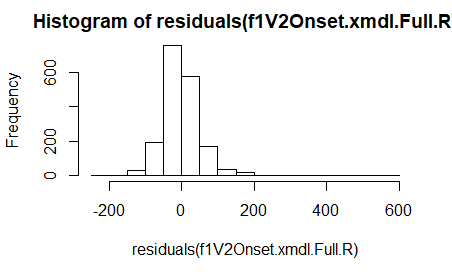

```r
hist(residuals(f1V2Onset.xmdl.Full.R))
```

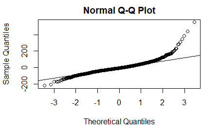

```r
qqnorm(residuals(f1V2Onset.xmdl.Full.R)); qqline(residuals(f1V2Onset.xmdl.Full.R))
```

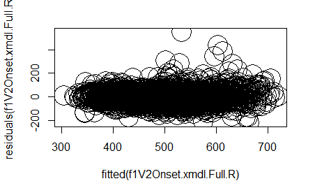

```r
plot(fitted(f1V2Onset.xmdl.Full.R),residuals(f1V2Onset.xmdl.Full.R), cex = 4)
```

##### 5.5.2.2.3 Summary of model

```r
summary(f1V2Onset.xmdl.Full.R)
```

```
Linear mixed model fit by REML. t-tests use Satterthwaite's method [
lmerModLmerTest]
Formula:
f1Onset ~ voiced.unvoiced_c + singGem_c + sex_c + vowelLength_c +
    syllType_c + place_c + (voiced.unvoiced_c + singGem_c + vowelLength_c +
    syllType_c + place_c || speaker) + (1 | wordTarget)
   Data: geminationV2
Control:
lmerControl(optimizer = "bobyqa", optCtrl = list(maxfun = 1e+05))

REML criterion at convergence: 19968.1

Scaled residuals:
    Min      1Q  Median      3Q     Max
-3.7533 -0.5218 -0.0820  0.4367  9.4623

Random effects:
 Groups     Name              Variance Std.Dev.
 wordTarget (Intercept)       1183.657 34.40
 speaker    place_c            923.620 30.39
 speaker.1  syllType_c         357.077 18.90
 speaker.2  vowelLength_c      403.158 20.08
 speaker.3  singGem_c            3.763  1.94
 speaker.4  voiced.unvoiced_c  641.256 25.32
 speaker.5  (Intercept)       1319.244 36.32
 Residual                     3383.564 58.17
Number of obs: 1793, groups:  wordTarget, 98; speaker, 20

Fixed effects:
                  Estimate Std. Error      df t value Pr(>|t|)
(Intercept)        451.219     10.548  41.734  42.778  < 2e-16 ***
voiced.unvoiced_c  -48.764     10.737  78.891  -4.542 1.98e-05 ***
singGem_c          -13.838      8.394  85.723  -1.649 0.102905
sex_c               66.262     16.766  17.982   3.952 0.000936 ***
vowelLength_c      -82.624      9.680  82.697  -8.536 5.69e-13 ***
syllType_c         -55.577     11.723  91.512  -4.741 7.78e-06 ***
place_c            -61.507     13.788  82.751  -4.461 2.55e-05 ***
---
Signif. codes:  0 ‘***’ 0.001 ‘**’ 0.01 ‘*’ 0.05 ‘.’ 0.1 ‘ ’ 1

Correlation of Fixed Effects:
            (Intr) vcd.n_ sngGm_ sex_c  vwlLn_ syllT_
vocd.nvcd_c  0.102
singGem_c   -0.169 -0.031
sex_c       -0.004  0.000  0.001
vowlLngth_c  0.185 -0.112  0.071  0.000
syllType_c   0.359  0.031 -0.359 -0.002  0.234
place_c      0.299  0.395 -0.011 -0.003 -0.045  0.025
```

#### 5.5.2.3 Figures

The figure presented below, uses the predicted (or fitted) values; these are the values *adjusted* by the statistical model. These take into account the random effects’ structure as well as the fixed effects’ structure.

##### 5.5.2.3.1 Using “predict”

The following code is used to record the predicted (or fitted) values into the same data-frame. This will then be used to plot the results of the model

```r
geminationV2$fitted_V2F1Onset <- predict(lmer(f1Onset~voiced.unvoiced_c+singGem_c+sex_c+vowelLength_c+syllType_c+place_c+
                                (voiced.unvoiced_c+singGem_c+vowelLength_c+syllType_c+place_c||speaker)+(1|wordTarget),
                              data = geminationV2,na.action=na.exclude,
                              REML=T,
                              control = lmerControl(optimizer = "bobyqa",optCtrl=list(maxfun=1e5)))
)
```

##### 5.5.2.3.2 Plotting the results

We use “ggplot2” to plot the results. This will use the “predicted” (or fitted) values adjusted by our statistical model. The dashed lines *within* the boxplots are the mean values; the median is marked by the horizontal straight lines.

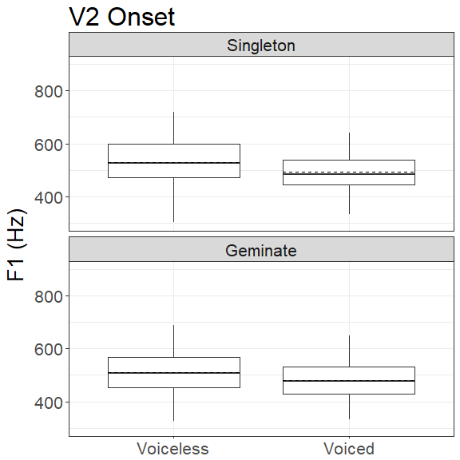

```r
labels <- c(singleton = "Singleton", geminate = "Geminate")
ggF1V2OnsetByVoice <- ggplot(geminationV2, aes(y=fitted_V2F1Onset, x=voiced.unvoiced)) +
  geom_boxplot(outlier.colour = "NA",na.rm=TRUE) +
  stat_summary(fun.y = mean, geom = "errorbar", aes(ymax = ..y.., ymin = ..y..),
               width = .75, linetype = "dashed") +
  ylab(expression(paste("F1 (Hz)"))) + labs(title = "V2 Onset") +
  theme_set(theme_bw()) + theme(text=element_text(size=20)) +
  coord_cartesian(ylim = c(300,900)) +
  theme(axis.title.x = element_blank()) + theme(legend.title=element_blank()) +
  scale_x_discrete(breaks=levels(geminationV2$voiced.unvoiced), labels=c("Voiceless","Voiced")) +
  facet_wrap(~singGem,ncol=1,labeller=labeller(singGem = labels))
ggF1V2OnsetByVoice
```

#### 5.5.2.4 Pairwise comparisons

After running our statistical model above, we wanted to evaluate whether the differences observed between “voicing” and “gemination” is statistically significant (or not). We present the means and standard deviations for each of the four-way contrast based on the predicted (or fitted) values.

##### 5.5.2.4.1 Descriptive statistics

The predicted means and SDs of the F1 at the Onset of the following vowel (V2Onset) are provided below. As can be seen, there are already differences observed related to both “voicing” and “gemination”.

```r
# using "dplyr"
geminationV2 %>% group_by(singGem:voiced.unvoiced) %>% summarise(mean(fitted_V2F1Onset), sd(fitted_V2F1Onset))
```

| singGem:voiced.unvoiced | mean(fitted_V2F1Onset) | sd(fitted_V2F1Onset) |
| --- | --- | --- |
| singleton:voiceless | 530.0481 | 93.72219 |
| singleton:voiced | 492.3613 | 65.47902 |
| geminate:voiceless | 511.1594 | 82.36532 |
| geminate:voiced | 480.7109 | 67.84863 |

##### 5.5.2.4.2 Pairwise t-test with FDR corrections

We used the pairwise t-test as available in base R. The input was the predicted (or fitted) values as adjusted by our statistical model. It was not possible to directly use our statistical model’s output to compare models, given that our LMM model was looking at overall change as a main effect rather than as a simple effect’s model. This is why we have used the predicted (or fitted) values as adjusted by our statistical model; the results are the same if we were to use the “actual” results rather than the predicted ones. We used FDR (for False Discovery Rate) correction for multiple comparisons as this allowed for correcting for bias in the differences in doing multiple comparisons.

```r
pairwise.t.test(geminationV2$fitted_V2F1Onset, geminationV2$singGem:geminationV2$voiced.unvoiced, p.adj = "fdr")
```

```
    Pairwise comparisons using t tests with pooled SD

data:  geminationV2$fitted_V2F1Onset and geminationV2$singGem:geminationV2$voiced.unvoiced

                   singleton:voiceless singleton:voiced
singleton:voiced   3.5e-11             -
geminate:voiceless 0.00103             0.00038
geminate:voiced    < 2e-16             0.01329
                   geminate:voiceless
singleton:voiced   -
geminate:voiceless -
geminate:voiced    9.5e-10

P value adjustment method: fdr
```

## 5.6 *H*1*-*H*2* (dB)

Within the differences between the normalised first and second harmonics to cue voice quality (*H*1*-*H*2*), we have computed *H*1*-*H*2* at two locations: At the Offset of the preceding vowel (V1Offset) and at the Onset of the following vowel (V2Offset).

### 5.6.1 At the offset of the preceding vowel

#### 5.6.1.1 Model specification

We run three models. For model comparisons, we are required to use Maximum Likelihood (ML) on both Optimal and Null models (by adding REML=F). Then we run a second Optimal models with Restricted Maximum Likelihood (REML), to obtain the coefficients (by adding REML=T)

##### 5.6.1.1.1 Optimal model (ML)

```r
h1mnh2V1Offset.xmdl.Full.M <- lmer(h1mnh2OffsetNorm~voiced.unvoiced_c+singGem_c+sex_c+vowelLength_c+syllType_c+place_c+
                                (voiced.unvoiced_c+singGem_c+vowelLength_c+syllType_c+place_c||speaker)+(1|wordTarget),
                              data = geminationV1,na.action=na.exclude,
                              REML=F,
                              control = lmerControl(optimizer = "bobyqa",optCtrl=list(maxfun=1e5)))
```

##### 5.6.1.1.2 Optimal model (REML)

```r
h1mnh2V1Offset.xmdl.Full.R <- lmer(h1mnh2OffsetNorm~voiced.unvoiced_c+singGem_c+sex_c+vowelLength_c+syllType_c+place_c+
                                (voiced.unvoiced_c+singGem_c+vowelLength_c+syllType_c+place_c||speaker)+(1|wordTarget),
                              data = geminationV1,na.action=na.exclude,
                              REML=T,
                              control = lmerControl(optimizer = "bobyqa",optCtrl=list(maxfun=1e5)))
```

##### 5.6.1.1.3 Null model (ML)

```r
h1mnh2V1Offset.xmdl.Null.M <- lmer(h1mnh2OffsetNorm~1+
                                (voiced.unvoiced_c+singGem_c+vowelLength_c+syllType_c+place_c||speaker)+(1|wordTarget),
                              data = geminationV1,na.action=na.exclude,
                              REML=F,
                              control = lmerControl(optimizer = "bobyqa",optCtrl=list(maxfun=1e5)))
```

#### 5.6.1.2 Results of our model

##### 5.6.1.2.1 Model comparisons

```r
anova(h1mnh2V1Offset.xmdl.Null.M,h1mnh2V1Offset.xmdl.Full.M)
```

```
Data: geminationV1
Models:
h1mnh2V1Offset.xmdl.Null.M: h1mnh2OffsetNorm ~ 1 + (voiced.unvoiced_c + singGem_c + vowelLength_c +
h1mnh2V1Offset.xmdl.Null.M:     syllType_c + place_c || speaker) + (1 | wordTarget)
h1mnh2V1Offset.xmdl.Full.M: h1mnh2OffsetNorm ~ voiced.unvoiced_c + singGem_c + sex_c + vowelLength_c +
h1mnh2V1Offset.xmdl.Full.M:     syllType_c + place_c + (voiced.unvoiced_c + singGem_c + vowelLength_c +
h1mnh2V1Offset.xmdl.Full.M:     syllType_c + place_c || speaker) + (1 | wordTarget)
                           Df    AIC    BIC  logLik deviance  Chisq
h1mnh2V1Offset.xmdl.Null.M  9 9135.3 9183.5 -4558.7   9117.3
h1mnh2V1Offset.xmdl.Full.M 15 9143.1 9223.4 -4556.5   9113.1 4.2286
                           Chi Df Pr(>Chisq)
h1mnh2V1Offset.xmdl.Null.M
h1mnh2V1Offset.xmdl.Full.M      6     0.6458
```

As can be seen, our optimal model did not improve the model fit. However, we will still use the optimal model to allow for comparison with the other models. This non-significant effect is indicative of a non-association between *H*1*-*H*2* and the predictors.

##### 5.6.1.2.2 Residuals

We inspect our model below, by looking at the residuals. There are minor deviations observed, due to the nature of our data.

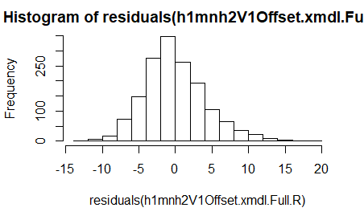

```r
hist(residuals(h1mnh2V1Offset.xmdl.Full.R))
```

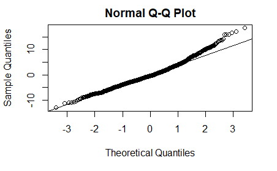

```r
qqnorm(residuals(h1mnh2V1Offset.xmdl.Full.R)); qqline(residuals(h1mnh2V1Offset.xmdl.Full.R))
```

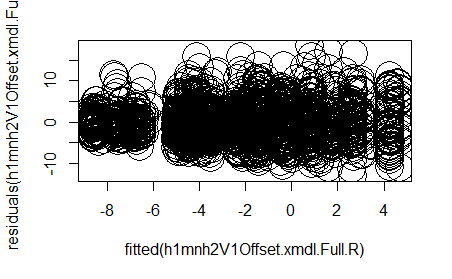

```r
plot(fitted(h1mnh2V1Offset.xmdl.Full.R),residuals(h1mnh2V1Offset.xmdl.Full.R), cex = 4)
```

##### 5.6.1.2.3 Summary of model

```r
summary(h1mnh2V1Offset.xmdl.Full.R)
```

```
Linear mixed model fit by REML. t-tests use Satterthwaite's method [
lmerModLmerTest]
Formula:
h1mnh2OffsetNorm ~ voiced.unvoiced_c + singGem_c + sex_c + vowelLength_c +
    syllType_c + place_c + (voiced.unvoiced_c + singGem_c + vowelLength_c +
    syllType_c + place_c || speaker) + (1 | wordTarget)
   Data: geminationV1
Control:
lmerControl(optimizer = "bobyqa", optCtrl = list(maxfun = 1e+05))

REML criterion at convergence: 9113

Scaled residuals:
    Min      1Q  Median      3Q     Max
-3.0232 -0.6442 -0.1055  0.5667  4.2980

Random effects:
 Groups     Name              Variance  Std.Dev.
 wordTarget (Intercept)       0.000e+00 0.000e+00
 speaker    place_c           2.997e-15 5.474e-08
 speaker.1  syllType_c        0.000e+00 0.000e+00
 speaker.2  vowelLength_c     7.493e-02 2.737e-01
 speaker.3  singGem_c         0.000e+00 0.000e+00
 speaker.4  voiced.unvoiced_c 1.638e-01 4.047e-01
 speaker.5  (Intercept)       1.194e+01 3.456e+00
 Residual                     1.872e+01 4.326e+00
Number of obs: 1567, groups:  wordTarget, 98; speaker, 20

Fixed effects:
                    Estimate Std. Error         df t value Pr(>|t|)
(Intercept)       -2.039e+00  7.979e-01  1.962e+01  -2.555   0.0191 *
voiced.unvoiced_c  5.505e-02  2.840e-01  3.357e+01   0.194   0.8475
singGem_c         -3.431e-03  2.452e-01  1.515e+03  -0.014   0.9888
sex_c              1.829e+00  1.561e+00  1.798e+01   1.172   0.2566
vowelLength_c      8.373e-02  2.593e-01  2.352e+01   0.323   0.7496
syllType_c         3.428e-01  3.223e-01  1.514e+03   1.064   0.2877
place_c            4.023e-01  3.550e-01  1.521e+03   1.133   0.2573
---
Signif. codes:  0 ‘***’ 0.001 ‘**’ 0.01 ‘*’ 0.05 ‘.’ 0.1 ‘ ’ 1

Correlation of Fixed Effects:
            (Intr) vcd.n_ sngGm_ sex_c  vwlLn_ syllT_
vocd.nvcd_c  0.041
singGem_c   -0.064 -0.026
sex_c       -0.001  0.003 -0.001
vowlLngth_c  0.080 -0.150  0.074 -0.001
syllType_c   0.150  0.034 -0.392 -0.001  0.264
place_c      0.134  0.509 -0.010  0.001 -0.065  0.030
```

#### 5.6.1.3 Figures

The figure presented below, uses the predicted (or fitted) values; these are the values *adjusted* by the statistical model. These take into account the random effects’ structure as well as the fixed effects’ structure.

##### 5.6.1.3.1 Using “predict”

The following code is used to record the predicted (or fitted) values into the same data-frame. This will then be used to plot the results of the model

```r
geminationV1$fitted_V1h1mnh2OffsetNorm <- predict(lmer(h1mnh2OffsetNorm~voiced.unvoiced_c+singGem_c+sex_c+vowelLength_c+syllType_c+place_c+
                                (voiced.unvoiced_c+singGem_c+vowelLength_c+syllType_c+place_c||speaker)+(1|wordTarget),
                              data = geminationV1,na.action=na.exclude,
                              REML=T,
                              control = lmerControl(optimizer = "bobyqa",optCtrl=list(maxfun=1e5)))
)
```

##### 5.6.1.3.2 Plotting the results

We use “ggplot2” to plot the results. This will use the “predicted” (or fitted) values adjusted by our statistical model. The dashed lines *within* the boxplots are the mean values; the median is marked by the horizontal straight lines.

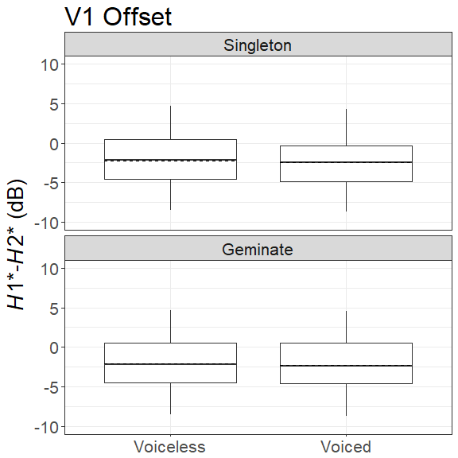

```r
labels <- c(singleton = "Singleton", geminate = "Geminate")
ggh1mnh2V1OffsetByVoice <- ggplot(geminationV1, aes(y=fitted_V1h1mnh2OffsetNorm, x=voiced.unvoiced)) +
  geom_boxplot(outlier.colour = "NA",na.rm=TRUE) +
  stat_summary(fun.y = mean, geom = "errorbar", aes(ymax = ..y.., ymin = ..y..),
               width = .75, linetype = "dashed") +
  ylab(expression(paste(italic("H"),"1*-",italic("H"),"2* (dB)"))) + labs(title = "V1 Offset") +
  theme_set(theme_bw()) + theme(text=element_text(size=20)) +
  coord_cartesian(ylim = c(-10,10)) +
  theme(axis.title.x = element_blank()) + theme(legend.title=element_blank()) +
  scale_x_discrete(breaks=levels(geminationV1$voiced.unvoiced), labels=c("Voiceless","Voiced")) +
  facet_wrap(~singGem,ncol=1,labeller=labeller(singGem = labels))
ggh1mnh2V1OffsetByVoice
```

#### 5.6.1.4 Pairwise comparisons

After running our statistical model above, we wanted to evaluate whether the differences observed between “voicing” and “gemination” is statistically significant (or not). We present the means and standard deviations for each of the four-way contrast based on the predicted (or fitted) values.

##### 5.6.1.4.1 Descriptive statistics

```r
# using "dplyr"
geminationV1 %>% group_by(singGem:voiced.unvoiced) %>% summarise(mean(fitted_V1h1mnh2OffsetNorm,na.rm = T), sd(fitted_V1h1mnh2OffsetNorm,na.rm = T))
```

| singGem:voiced.unvoiced | mean(fitted_V1h1mnh2OffsetNorm, na.rm = T) | sd(fitted_V1h1mnh2OffsetNorm, na.rm = T) |
| --- | --- | --- |
| singleton:voiceless | -2.218801 | 3.420897 |
| singleton:voiced | -2.416163 | 3.435975 |
| geminate:voiceless | -2.132873 | 3.276781 |
| geminate:voiced | -2.268406 | 3.422969 |

##### 5.6.1.4.2 Pairwise t-test with FDR corrections

We used the pairwise t-test as available in base R. The input was the predicted (or fitted) values as adjusted by our statistical model. It was not possible to directly use our statistical model’s output to compare models, given that our LMM model was looking at overall change as a main effect rather than as a simple effect’s model. This is why we have used the predicted (or fitted) values as adjusted by our statistical model; the results are the same if we were to use the “actual” results rather than the predicted ones. We used FDR (for False Discovery Rate) correction for multiple comparisons as this allowed for correcting for bias in the differences in doing multiple comparisons.

```r
pairwise.t.test(geminationV1$fitted_V1h1mnh2OffsetNorm, geminationV1$singGem:geminationV1$voiced.unvoiced, p.adj = "fdr")
```

```
    Pairwise comparisons using t tests with pooled SD

data:  geminationV1$fitted_V1h1mnh2OffsetNorm and geminationV1$singGem:geminationV1$voiced.unvoiced

                   singleton:voiceless singleton:voiced
singleton:voiced   0.84                -
geminate:voiceless 0.85                0.84
geminate:voiced    0.85                0.84
                   geminate:voiceless
singleton:voiced   -
geminate:voiceless -
geminate:voiced    0.84

P value adjustment method: fdr
```

### 5.6.2 At the onset of the following vowel

#### 5.6.2.1 Model specification

We run three models. For model comparisons, we are required to use Maximum Likelihood (ML) on both Optimal and Null models (by adding REML=F). Then we run a second Optimal models with Restricted Maximum Likelihood (REML), to obtain the coefficients (by adding REML=T)

##### 5.6.2.1.1 Optimal model (ML)

```r
h1mnh2V2Onset.xmdl.Full.M <- lmer(h1mnh2OnsetNorm~voiced.unvoiced_c+singGem_c+sex_c+vowelLength_c+syllType_c+place_c+
                                (voiced.unvoiced_c+singGem_c+vowelLength_c+syllType_c+place_c||speaker)+(1|wordTarget),
                              data = geminationV2,na.action=na.exclude,
                              REML=F,
                              control = lmerControl(optimizer = "bobyqa",optCtrl=list(maxfun=1e5)))
```

##### 5.6.2.1.2 Optimal model (REML)

```r
h1mnh2V2Onset.xmdl.Full.R <- lmer(h1mnh2OnsetNorm~voiced.unvoiced_c+singGem_c+sex_c+vowelLength_c+syllType_c+place_c+
                                (voiced.unvoiced_c+singGem_c+vowelLength_c+syllType_c+place_c||speaker)+(1|wordTarget),
                              data = geminationV2,na.action=na.exclude,
                              REML=T,
                              control = lmerControl(optimizer = "bobyqa",optCtrl=list(maxfun=1e5)))
```

##### 5.6.2.1.3 Null model (ML)

```r
h1mnh2V2Onset.xmdl.Null.M <- lmer(h1mnh2OnsetNorm~1+
                                (voiced.unvoiced_c+singGem_c+vowelLength_c+syllType_c+place_c||speaker)+(1|wordTarget),
                              data = geminationV2,na.action=na.exclude,
                              REML=F,
                              control = lmerControl(optimizer = "bobyqa",optCtrl=list(maxfun=1e5)))
```

#### 5.6.2.2 Results of our model

##### 5.6.2.2.1 Model comparisons

```r
anova(h1mnh2V2Onset.xmdl.Null.M,h1mnh2V2Onset.xmdl.Full.M)
```

```
Data: geminationV2
Models:
h1mnh2V2Onset.xmdl.Null.M: h1mnh2OnsetNorm ~ 1 + (voiced.unvoiced_c + singGem_c + vowelLength_c +
h1mnh2V2Onset.xmdl.Null.M:     syllType_c + place_c || speaker) + (1 | wordTarget)
h1mnh2V2Onset.xmdl.Full.M: h1mnh2OnsetNorm ~ voiced.unvoiced_c + singGem_c + sex_c + vowelLength_c +
h1mnh2V2Onset.xmdl.Full.M:     syllType_c + place_c + (voiced.unvoiced_c + singGem_c + vowelLength_c +
h1mnh2V2Onset.xmdl.Full.M:     syllType_c + place_c || speaker) + (1 | wordTarget)
                          Df   AIC   BIC  logLik deviance  Chisq
h1mnh2V2Onset.xmdl.Null.M  9 10989 11039 -5485.7    10971
h1mnh2V2Onset.xmdl.Full.M 15 10988 11070 -5478.7    10958 13.965
                          Chi Df Pr(>Chisq)
h1mnh2V2Onset.xmdl.Null.M
h1mnh2V2Onset.xmdl.Full.M      6    0.03003 *
---
Signif. codes:  0 ‘***’ 0.001 ‘**’ 0.01 ‘*’ 0.05 ‘.’ 0.1 ‘ ’ 1
```

As can be seen, our optimal model improved the model fit.

##### 5.6.2.2.2 Residuals

We inspect our model below, by looking at the residuals. There are minor deviations observed, due to the nature of our data.

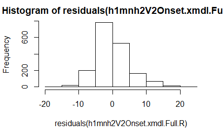

```r
hist(residuals(h1mnh2V2Onset.xmdl.Full.R))
```

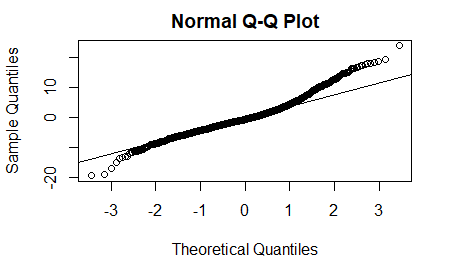

```r
qqnorm(residuals(h1mnh2V2Onset.xmdl.Full.R)); qqline(residuals(h1mnh2V2Onset.xmdl.Full.R))
```

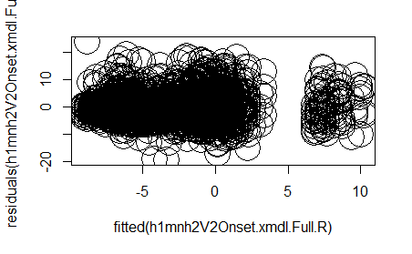

```r
plot(fitted(h1mnh2V2Onset.xmdl.Full.R),residuals(h1mnh2V2Onset.xmdl.Full.R), cex = 4)
```

##### 5.6.2.2.3 Summary of model

```r
summary(h1mnh2V2Onset.xmdl.Full.R)
```

```
Linear mixed model fit by REML. t-tests use Satterthwaite's method [
lmerModLmerTest]
Formula:
h1mnh2OnsetNorm ~ voiced.unvoiced_c + singGem_c + sex_c + vowelLength_c +
    syllType_c + place_c + (voiced.unvoiced_c + singGem_c + vowelLength_c +
    syllType_c + place_c || speaker) + (1 | wordTarget)
   Data: geminationV2
Control:
lmerControl(optimizer = "bobyqa", optCtrl = list(maxfun = 1e+05))

REML criterion at convergence: 10955.2

Scaled residuals:
    Min      1Q  Median      3Q     Max
-3.8200 -0.5976 -0.1252  0.4466  4.7005

Random effects:
 Groups     Name              Variance  Std.Dev.
 wordTarget (Intercept)       0.000e+00 0.000e+00
 speaker    place_c           1.303e+00 1.141e+00
 speaker.1  syllType_c        0.000e+00 0.000e+00
 speaker.2  vowelLength_c     5.084e-12 2.255e-06
 speaker.3  singGem_c         2.356e-01 4.854e-01
 speaker.4  voiced.unvoiced_c 5.053e-01 7.109e-01
 speaker.5  (Intercept)       1.506e+01 3.881e+00
 Residual                     2.595e+01 5.094e+00
Number of obs: 1783, groups:  wordTarget, 98; speaker, 20

Fixed effects:
                   Estimate Std. Error        df t value Pr(>|t|)
(Intercept)         -2.2902     0.8945   19.2938  -2.560   0.0190 *
voiced.unvoiced_c   -0.1869     0.3347   25.0199  -0.558   0.5816
singGem_c           -0.7220     0.2933   27.0620  -2.462   0.0205 *
sex_c                2.6897     1.7578   17.9598   1.530   0.1434
vowelLength_c       -0.2544     0.2779 1713.4068  -0.915   0.3601
syllType_c           0.3365     0.3524 1710.6079   0.955   0.3397
place_c              0.8090     0.4643   23.3301   1.742   0.0946 .
---
Signif. codes:  0 ‘***’ 0.001 ‘**’ 0.01 ‘*’ 0.05 ‘.’ 0.1 ‘ ’ 1

Correlation of Fixed Effects:
            (Intr) vcd.n_ sngGm_ sex_c  vwlLn_ syllT_
vocd.nvcd_c  0.041
singGem_c   -0.058 -0.032
sex_c       -0.001  0.001  0.001
vowlLngth_c  0.080 -0.130  0.073  0.001
syllType_c   0.145  0.042 -0.372  0.000  0.281
place_c      0.110  0.392 -0.010 -0.002 -0.050  0.031
```

#### 5.6.2.3 Figures

The figure presented below, uses the predicted (or fitted) values; these are the values *adjusted* by the statistical model. These take into account the random effects’ structure as well as the fixed effects’ structure.

##### 5.6.2.3.1 Using “predict”

The following code is used to record the predicted (or fitted) values into the same data-frame. This will then be used to plot the results of the model

```r
geminationV2$fitted_V2h1mnh2OnsetNorm <- predict(lmer(h1mnh2OnsetNorm~voiced.unvoiced_c+singGem_c+sex_c+vowelLength_c+syllType_c+place_c+
                                (voiced.unvoiced_c+singGem_c+vowelLength_c+syllType_c+place_c||speaker)+(1|wordTarget),
                              data = geminationV2,na.action=na.exclude,
                              REML=T,
                              control = lmerControl(optimizer = "bobyqa",optCtrl=list(maxfun=1e5)))
)
```

##### 5.6.2.3.2 Plotting the results

We use “ggplot2” to plot the results. This will use the “predicted” (or fitted) values adjusted by our statistical model. The dashed lines *within* the boxplots are the mean values; the median is marked by the horizontal straight lines.

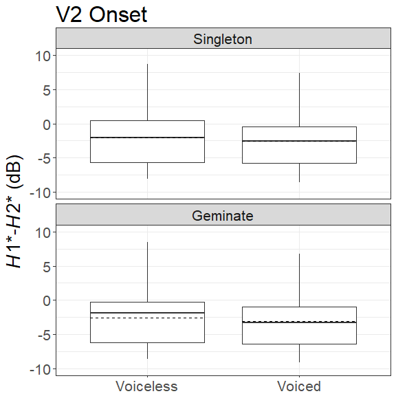

```r
labels <- c(singleton = "Singleton", geminate = "Geminate")
ggh1mnh2V2OnsetByVoice <- ggplot(geminationV2, aes(y=fitted_V2h1mnh2OnsetNorm, x=voiced.unvoiced)) +
  geom_boxplot(outlier.colour = "NA",na.rm=TRUE) +
  stat_summary(fun.y = mean, geom = "errorbar", aes(ymax = ..y.., ymin = ..y..),
               width = .75, linetype = "dashed") +
  ylab(expression(paste(italic("H"),"1*-",italic("H"),"2* (dB)"))) + labs(title = "V2 Onset") +
  theme_set(theme_bw()) + theme(text=element_text(size=20)) +
  coord_cartesian(ylim = c(-10,10)) +
  theme(axis.title.x = element_blank()) + theme(legend.title=element_blank()) +
  scale_x_discrete(breaks=levels(geminationV2$voiced.unvoiced), labels=c("Voiceless","Voiced")) +
  facet_wrap(~singGem,ncol=1,labeller=labeller(singGem = labels))
ggh1mnh2V2OnsetByVoice
```

#### 5.6.2.4 Pairwise comparisons

After running our statistical model above, we wanted to evaluate whether the differences observed between “voicing” and “gemination” is statistically significant (or not). We present the means and standard deviations for each of the four-way contrast based on the predicted (or fitted) values.

##### 5.6.2.4.1 Descriptive statistics

The predicted means and SDs of the *H*1*-*H*2* at the Onset of the following vowel (V2Onset) are provided below. As can be seen, there are already differences observed related to both “voicing” and “gemination”.

```r
# using "dplyr"
geminationV2 %>% group_by(singGem:voiced.unvoiced) %>% summarise(mean(fitted_V2h1mnh2OnsetNorm,na.rm = T), sd(fitted_V2h1mnh2OnsetNorm,na.rm = T))
```

| singGem:voiced.unvoiced | mean(fitted_V2h1mnh2OnsetNorm, na.rm = T) | sd(fitted_V2h1mnh2OnsetNorm, na.rm = T) |
| --- | --- | --- |
| singleton:voiceless | -2.005195 | 4.057387 |
| singleton:voiced | -2.600651 | 3.771195 |
| geminate:voiceless | -2.560383 | 4.058466 |
| geminate:voiced | -3.143139 | 3.774406 |

##### 5.6.2.4.2 Pairwise t-test with FDR corrections

We used the pairwise t-test as available in base R. The input was the predicted (or fitted) values as adjusted by our statistical model. It was not possible to directly use our statistical model’s output to compare models, given that our LMM model was looking at overall change as a main effect rather than as a simple effect’s model. This is why we have used the predicted (or fitted) values as adjusted by our statistical model; the results are the same if we were to use the “actual” results rather than the predicted ones. We used FDR (for False Discovery Rate) correction for multiple comparisons as this allowed for correcting for bias in the differences in doing multiple comparisons.

```r
pairwise.t.test(geminationV2$fitted_V2h1mnh2OnsetNorm, geminationV2$singGem:geminationV2$voiced.unvoiced, p.adj = "fdr")
```

```
    Pairwise comparisons using t tests with pooled SD

data:  geminationV2$fitted_V2h1mnh2OnsetNorm and geminationV2$singGem:geminationV2$voiced.unvoiced

                   singleton:voiceless singleton:voiced
singleton:voiced   0.05387             -
geminate:voiceless 0.06751             0.87847
geminate:voiced    0.00017             0.04972
                   geminate:voiceless
singleton:voiced   -
geminate:voiceless -
geminate:voiced    0.04972

P value adjustment method: fdr
```